# Анализ поведения пользователей сервиса Яндекс Афиша

Заказчик — сервис Яндекс Афиша, с помощью которого пользователи могут узнавать информацию о мероприятиях в разных городах и покупать на них билеты. Сервис сотрудничает с партнёрами — организаторами мероприятий и билетными операторами, которые предоставляют информацию о событиях и выставляют билеты на продажу.

В ноябре 2024 года сотрудники из отдела продукта увидели, что продажи билетов на одни мероприятия неожиданно растут, а на другие — снижаются. В чём причина, пока не ясно. Близится период распродаж и новогодних акций, и сервис должен основательно к нему подготовиться.

Необходимо:

1. Разработать аналитический дашборд в Yandex DataLens. С его помощью команда сможет отслеживать динамику ключевых бизнес-показателей, анализировать популярность мероприятий и структуру выручки в разрезе категорий событий и устройств.
2. Провести исследовательский анализ данных в Python. Это поможет сделать выводы об изменении пользовательских предпочтений и популярности событий осенью 2024 года, а также проверить гипотезу о разнице в поведении пользователей с мобильных и стационарных устройств. Такой анализ дополнит данные дашборда и поможет команде продукта получить инсайты об изменении пользовательских предпочтений.

# Часть 1: Анализ данных с помощью SQL и создание дашборда в DataLens

## Описание данных

В нашем распоряжении пять таблиц:

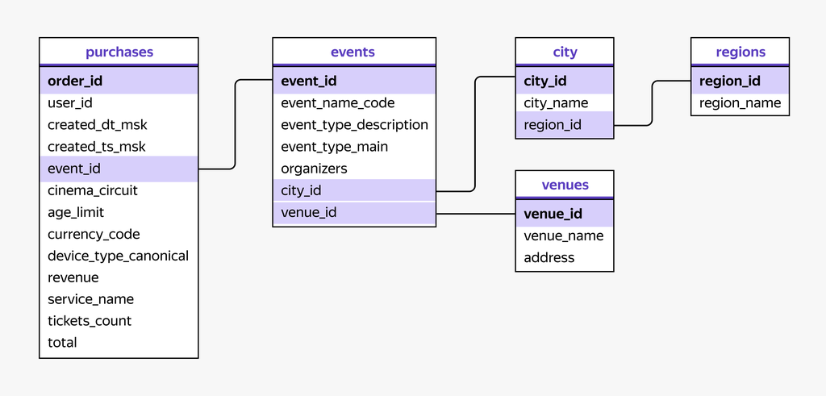

Таблица `purchases` содержит информацию о заказах билетов:

- `order_id` — уникальный идентификатор заказа.
- `user_id` — уникальный идентификатор пользователя.
- `created_dt_msk` — дата создания заказа (московское время).
- `created_ts_msk` — дата и время создания заказа (московское время).
- `event_id` — идентификатор мероприятия из таблицы events.
- `cinema_circuit` — сеть кинотеатров. Если не применимо, то здесь будет значение 'нет'.
- `age_limit` — возрастное ограничение мероприятия.
- `currency_code` — валюта оплаты, например rub для российских рублей.
- `device_type_canonical` — тип устройства, с которого был оформлен заказ, например mobile для мобильных устройств, desktop для стационарных.
- `revenue` — выручка от заказа.
- `service_name` — название билетного оператора.
- `tickets_count` — количество купленных билетов.
- `total` — общая сумма заказа.

Таблица `events` содержит данные о мероприятиях:

- `event_id` — уникальный идентификатор мероприятия.
- `event_name_code` — название мероприятия в закодированном виде.
- `event_type_description` — описание мероприятия.
- `event_type_main` — основной тип мероприятия: театральная постановка, концерт и так далее.
- `organizers` — организаторы мероприятия.
- `city_id` — идентификатор города проведения мероприятия из таблицы `cities`.
- `venue_id` — идентификатор площадки проведения мероприятия из таблицы `venues`.

Таблица `venues` содержит сведения о площадках проведения мероприятий:

- `venue_id` — уникальный идентификатор площадки.
- `venue_name` — название площадки.
- `address` — адрес площадки.

Таблица `city` содержит список городов:

- `city_id` — уникальный идентификатор города.
- `city_name` — название города.
- `region_id` — идентификатор региона, к которому относится город, из таблицы `regions`.

Таблица `regions` содержит список регионов:

- `region_id` — уникальный идентификатор региона.
- `region_name` — название региона.

Данные предоставлены сервисом в **анонимизированном виде**.

# Цель

Проверить корректность данных, изучить ключевые метрики продукта, разработать аналитический дашборд в Yandex DataLens.

## 1. Изучение и проверка корректности данных

Для начала изучим данные таблицы `purchases`. Проверим уникальность идентификаторов, а также узначем число пользователей.

```python
SELECT COUNT(*) AS total_count, COUNT(DISTINCT order_id) AS total_orders, COUNT(DISTINCT user_id) AS total_users
FROM purchases
```

| total_count | total_orders | total_users |  |
| --- | --- | --- | --- |
| 292034 | 292034 | 22000 |  |

Дубликаты в данных с номером заказа отсутствуют, данные содержат информацию о 292034 заказах, совершённых 22000 пользователей. Данных достаточно, чтобы провести их качественный анализ.

Посмотрим на распределение заказов по основным категориям, начнем с возрастного ограничения мероприятий.

```python
SELECT age_limit, COUNT(order_id)
FROM purchases
GROUP BY age_limit
ORDER BY COUNT(order_id) DESC
```

| age_limit | count |  |
| --- | --- | --- |
| 16 | 78864 |  |
| 12 | 62861 |  |
| 0 | 61731 |  |
| 6 | 52403 |  |
| 18 | 36175 |  |

Категории мероприятий с возрастными ограничениями 16+ и 12+ являются самими популярными.

Теперь посмотрим на распределение заказов по типам устройств.

```python
SELECT device_type_canonical, COUNT(order_id)
FROM purchases
GROUP BY device_type_canonical
ORDER BY COUNT(order_id) DESC
```

| device_type_canonical | count |  |
| --- | --- | --- |
| mobile | 232679 |  |
| desktop | 58170 |  |
| tablet | 1180 |  |
| tv | 3 |  |
| other | 2 |  |

В данных всего пять типов устройств, и наиболее популярные среди них — мобильные устройства и стационарные компьютеры. Затем следуют планшеты, а вот телевизоры и другие устройства представлены единичными заказами.

Изучим распределение по видам мероприятий.

```python
SELECT event_type_main, COUNT(order_id)
FROM purchases
LEFT JOIN events ON purchases.event_id = events.event_id
GROUP BY event_type_main
ORDER BY COUNT(order_id) DESC
```

| event_type_main | count |  |
| --- | --- | --- |
| концерты | 115634 |  |
| театр | 67744 |  |
| другое | 66109 |  |
| спорт | 22006 |  |
| стендап | 13424 |  |
| выставки | 4873 |  |
| ёлки | 2006 |  |
| фильм | 238 |  |

Концерты, театры и некое "другое" являются наиболее популярными видами мероприятий.

Значения выручки с бронирования билетов и общей стоимости заказа могут быть в разных валютах. Посмотрим, какие валюты встречаются в данных.

```python
SELECT currency_code, COUNT(order_id)
FROM purchases
GROUP BY currency_code
ORDER BY COUNT(order_id) DESC
```

| currency_code | count |  |
| --- | --- | --- |
| rub | 286961 |  |
| kzt | 5073 |  |

Большая часть данных представлена в российских рублях, часть заказов представлена в казахстанской валюте.

Изучим период времени, за который представлены данные.

```python
SELECT MIN(created_dt_msk), MAX(created_dt_msk)
FROM purchases
```

| min | max |  |
| --- | --- | --- |
| 2024-06-01 00:00:00.000 | 2024-10-31 00:00:00.000 |  |

Данные охватывают весь летний период и два месяца осени 2024 года. Это нужно учитывать, поскольку популярность событий разного типа может меняться в зависимости от времени года. Помимо этого, одна из задач проекта — исследование влияния сезонности на предпочтения пользователей.

Проверим данные таблицы `purchases` на наличие пропусков.

```python
SELECT count(order_id)
FROM purchases
WHERE user_id IS NULL OR event_id IS NULL OR cinema_circuit IS NULL OR age_limit IS NULL OR
    device_type_canonical IS NULL OR tickets_count IS NULL OR revenue IS NULL OR age_limit IS NULL
```

[output not shown]

Пропущенные значения отсутствуют.

Изучим статистические показатели по полю `revenue` в разрезе разных валют.

```python
SELECT currency_code, MIN(revenue), MAX(revenue), ROUND(AVG(revenue)::numeric, 2) AS avg,
    PERCENTILE_DISC(0.5) within group (order by revenue) AS median,
    ROUND(stddev(revenue)::numeric, 2) AS stddev
FROM purchases
GROUP BY currency_code
```

| currency_code | min | max | avg | median | stddev |  |
| --- | --- | --- | --- | --- | --- | --- |
| kzt | 0.0 | 26425.86 | 4995.31 | 3698.83 | 4916.64 |  |
| rub | -90.76 | 81174.54 | 547.57 | 346.18 | 870.62 |  |

В поле `revenue` максимальное значение в рублях достигает около 81 тысячи — это значительно выше среднего значения — около 550 рублей при стандартном отклонении порядка 870. Также встречаются бронирования билетов с отрицательными значениями выручки в российских рублях. Вероятно, это возвраты заказа.

Теперь изучим данные таблиц `events`, `city`, `regions`, `venues`.

```python
SELECT COUNT(*) AS total_count, COUNT(DISTINCT event_id) AS total_events, COUNT(DISTINCT event_name_code) AS total_events_code
FROM events
```

| total_count | total_events | total_events_code |  |
| --- | --- | --- | --- |
| 22484 | 22484 | 15287 |  |

```python
SELECT count(event_id)
FROM events
WHERE event_type_main IS NULL OR organizers IS NULL OR city_id IS NULL OR venue_id IS NULL
```

| count |  |
| --- | --- |
| 0 |  |

Идентификаторы в таблице `events` уникальны. Количество уникальных событий по event_id больше, чем по идентификатору названия события event_name_code. Это объясняется тем, что одно и то же событие могло проводиться в разных городах на разных площадках. Пропуски в данных отсутствуют.

```python
SELECT COUNT(*) AS total_count, COUNT(DISTINCT city_id) AS total_cities
FROM city
```

| total_count | total_cities |  |
| --- | --- | --- |
| 353 | 353 |  |

```python
SELECT count(city_id)
FROM city
WHERE city_name IS NULL OR region_id IS NULL
```

| count |  |
| --- | --- |
| 0 |  |

```python
SELECT COUNT(*) AS total_count, COUNT(DISTINCT region_id) AS total_regions
FROM regions
```

| total_count | total_regions |  |
| --- | --- | --- |
| 81 | 81 |  |

```python
SELECT count(region_id)
FROM regions
WHERE region_name IS NULL
```

| count |  |
| --- | --- |
| 0 |  |

Идентификаторы в таблицах `city` и `regions` уникальны, пропуски отсутствуют. Данные имеют широкий региональный охват: 353 города и 81 регион.

```python
SELECT COUNT(*) AS total_count, COUNT(DISTINCT venue_id) AS total_venues
FROM venues
```

| total_count | total_venues |  |
| --- | --- | --- |
| 3228 | 3228 |  |

```python
SELECT count(venue_id)
FROM venues
WHERE venue_name IS NULL OR address IS NULL
```

| count |  |
| --- | --- |
| 0 |  |

Идентификаторы в таблице `venues` уникальны, пропуски отсутствуют. Данные содержат сведения о 3228 площадках для проведения мероприятий.

## 2. Изучение ключевых метрик продукта

В структуре дохода сервиса, аналогичного Яндекс Афише, можно выделить две категории выручки: ту, которую получают за счёт комиссии от продажи билетов и сервисного сбора, а также дополнительную выручку за счёт платного размещения объявлений, рекламы и партнёрских программ. В нашем распоряжении есть данные только о выручке с продажи или бронирования билетов — поле `revenue`. Сюда входит и комиссия от продажи, и сервисный сбор.  
Выручка сервиса является одним из главных показателей, который показывает эффективность продукта. На общую выручку влияют следующие факторы: количество заказов, средняя стоимость билета, среднее количество билетов в заказе.  
Вычислим базовые значения выручки сервиса и остальных показателей, это понадобится в дальнейшем для построения дашборда.

### 2.1. Получение общих данных

Вычислим общие значения ключевых показателей сервиса за весь период:

- общая выручка с заказов total_revenue;
- количество заказов total_orders;
- средняя выручка заказа avg_revenue_per_order;
- общее число уникальных клиентов total_users.

Поскольку данные представлены в российских рублях и казахстанских тенге, то значения посчитаем в разрезе каждой валюты.

```python
SELECT currency_code, SUM(revenue) AS total_revenue,
    COUNT(order_id) AS total_orders,
    ROUND(AVG(revenue)::numeric, 2) AS avg_revenue_per_order,
    COUNT(DISTINCT user_id) AS total_users
FROM afisha.purchases
GROUP BY currency_code
ORDER BY total_revenue DESC
```

| currency_code | total_revenue | total_orders | avg_revenue_per_order | total_users |  |
| --- | --- | --- | --- | --- | --- |
| rub | 157130432 | 286961 | 547.57 | 21422 |  |
| kzt | 25340978 | 5073 | 4995.31 | 1362 |  |

Заказов билетов в казахстанских тенге намного меньше, чем в российских рублях — чуть меньше 2%. Однако при дальнейшем анализе их всё равно следует учитывать.

### 2.2. Изучение распределения выручки в разрезе устройств

Для заказов в рублях вычислим распределение выручки и количества заказов по типу устройства device_type_canonical. В результат включим поля:

- тип устройства device_type_canonical;
- общая выручка с заказов total_revenue;
- количество заказов total_orders;
- средняя стоимость заказа avg_revenue_per_order;
- доля выручки для каждого устройства от общего значения revenue_share, округлённая до трёх знаков после точки.

```python
SELECT device_type_canonical,
    SUM(revenue) AS total_revenue,
    COUNT(order_id) AS total_orders,
    ROUND(AVG(revenue)::numeric,2) AS avg_revenue_per_order,
    ROUND((SUM(revenue)/ SUM(SUM(revenue)) OVER ())::numeric, 3) AS revenue_share
FROM afisha.purchases
WHERE currency_code = 'rub'
GROUP BY device_type_canonical
ORDER BY revenue_share DESC
```

| device_type_canonical | total_revenue | total_orders | avg_revenue_per_order | revenue_share |  |
| --- | --- | --- | --- | --- | --- |
| mobile | 124633528 | 229021 | 544.20 | 0.793 |  |
| desktop | 31851612 | 56759 | 561.17 | 0.203 |  |
| tablet | 640988.7 | 1176 | 545.06 | 0.004 |  |
| other | 5133.7603 | 2 | 2566.88 | 0.000 |  |
| tv | 1299.16 | 3 | 433.05 | 0.000 |  |

По результатам видно, что основная часть выручки приходится на мобильные устройства и стационарные компьютеры. Доля остальных устройств в структуре выручки минимальна и составляет меньше процента.

### 2.3. Изучение распределения выручки в разрезе типа мероприятий

Для заказов в рублях вычислии распределение количества заказов и их выручку в зависимости от типа мероприятия event_type_main. В результат включим поля:

- тип мероприятия event_type_main;
- общая выручка с заказов total_revenue;
- количество заказов total_orders;
- средняя стоимость заказа avg_revenue_per_order;
- уникальное число событий total_event_name (по их коду event_name_code);
- среднее число билетов в заказе avg_tickets;
- средняя выручка с одного билета avg_ticket_revenue;
- доля выручки от общего значения revenue_share, округлённая до трёх знаков после точки.

```python
SELECT event_type_main,
    SUM(revenue::numeric) AS total_revenue,
    COUNT(order_id) AS total_orders,
    ROUND(AVG(revenue)::numeric, 2) AS avg_revenue_per_order,
    COUNT(DISTINCT event_name_code) AS total_event_name,
    ROUND(AVG(tickets_count)::numeric, 2) AS avg_tickets,
    ROUND((SUM(revenue) / SUM(tickets_count))::numeric, 2) AS avg_ticket_revenue,
    ROUND((SUM(revenue)/ SUM(SUM(revenue)) OVER ())::numeric, 3) AS revenue_share
FROM afisha.purchases as purchases
INNER JOIN afisha.events as events ON purchases.event_id = events.event_id
WHERE currency_code = 'rub'
GROUP BY event_type_main
ORDER BY total_orders DESC;
```

| event_type_main | total_revenue | total_orders | avg_revenue_per_order | total_event_name | avg_tickets | avg_ticket_revenue | revenue_share |  |
| --- | --- | --- | --- | --- | --- | --- | --- | --- |
| концерты | 88707358.44 | 112418 | 789.09 | 6014 | 2.66 | 296.97 | 0.565 |  |
| театр | 37141852.69 | 67733 | 548.36 | 4352 | 2.76 | 198.67 | 0.236 |  |
| другое | 15580063.97 | 64572 | 241.28 | 3807 | 2.76 | 87.27 | 0.099 |  |
| спорт | 3466664.86 | 21700 | 159.75 | 785 | 3.05 | 52.32 | 0.022 |  |
| стендап | 9547221.52 | 13421 | 711.36 | 420 | 2.99 | 237.76 | 0.061 |  |
| выставки | 1135896.43 | 4873 | 233.10 | 279 | 2.56 | 91.12 | 0.007 |  |
| ёлки | 1549354.86 | 2006 | 772.36 | 173 | 3.34 | 231.07 | 0.010 |  |
| фильм | 3084.81 | 238 | 12.96 | 19 | 2.66 | 4.88 | 0.000 |  |

Среди наиболее популярных событий — концерты, театральные постановки и загадочное «другое».

### 2.4. Динамика изменения значений

На дашборде понадобится показать динамику изменения ключевых метрик и параметров. Для заказов в рублях вычислим изменение выручки, количества заказов, уникальных клиентов и средней стоимости одного заказа в недельной динамике:

- неделя week;
- суммарная выручка total_revenue;
- число заказов total_orders;
- уникальное число клиентов total_users;
- средняя стоимость одного заказа revenue_per_order.

```python
SELECT DATE_TRUNC('week', created_dt_msk)::date AS week,
    SUM(revenue) AS total_revenue,
    COUNT(order_id) AS total_orders,
    COUNT(DISTINCT user_id) AS total_users,
    SUM(revenue)/ COUNT(order_id) AS revenue_per_order
FROM afisha.purchases
WHERE currency_code = 'rub'
GROUP BY week
ORDER BY week
```

| week | total_revenue | total_orders | total_users | revenue_per_order |  |
| --- | --- | --- | --- | --- | --- |
| 2024-05-27 | 911625.7 | 2024 | 805 | 450.4079483695652 |  |
| 2024-06-03 | 3989499.0 | 7589 | 2238 | 525.6949532217684 |  |
| 2024-06-10 | 4160552.8 | 7431 | 2153 | 559.8913672453236 |  |
| 2024-06-17 | 4612188.5 | 8043 | 2143 | 573.4413154295661 |  |
| 2024-06-24 | 4243699.5 | 7362 | 2032 | 576.432966585167 |  |
| 2024-07-01 | 5159818.0 | 8995 | 2296 | 573.6317954419121 |  |
| 2024-07-08 | 5511003.5 | 8980 | 2310 | 613.6974944320713 |  |
| 2024-07-15 | 5580839.5 | 8836 | 2406 | 631.6024784970575 |  |
| 2024-07-22 | 5457105.0 | 9347 | 2421 | 583.8349202952819 |  |
| 2024-07-29 | 5846354.0 | 10536 | 2492 | 554.8931283219438 |  |
| 2024-08-05 | 6235618.0 | 9642 | 2546 | 646.7141671852313 |  |
| 2024-08-12 | 6081583.5 | 9719 | 2596 | 625.7416915320506 |  |
| 2024-08-19 | 5823034.0 | 10488 | 2654 | 555.2091914569031 |  |
| 2024-08-26 | 5701595.5 | 10157 | 2527 | 561.3464113419317 |  |
| 2024-09-02 | 6926397.0 | 15642 | 3075 | 442.80763329497506 |  |
| 2024-09-09 | 8349239.5 | 15706 | 3431 | 531.5955367375525 |  |
| 2024-09-16 | 9044700.0 | 16599 | 3509 | 544.8942707392011 |  |
| 2024-09-23 | 9865479.0 | 17554 | 3768 | 562.0074626865671 |  |
| 2024-09-30 | 11440865 | 23031 | 4071 | 496.7593678086058 |  |
| 2024-10-07 | 10978249 | 19420 | 4118 | 565.306333676622 |  |
| 2024-10-14 | 12096955 | 22438 | 4420 | 539.1280417149478 |  |
| 2024-10-21 | 12207041 | 22810 | 4475 | 535.161814993424 |  |
| 2024-10-28 | 6907851.0 | 14612 | 3019 | 472.751916233233 |  |

Виден рост количества заказов и пользователей к концу временного периода.

### 2.5. Выделение топ-сегментов

Выведем топ-7 регионов по значению общей выручки, включив только заказы за рубли:

- название региона region_name;
- суммарная выручка total_revenue;
- число заказов total_orders;
- уникальное число клиентов total_users;
- количество проданных билетов total_tickets;
- средняя выручка одного билета one_ticket_cost.

```python
SELECT region_name,
    SUM(revenue) AS total_revenue,
    COUNT(order_id) AS total_orders,
    COUNT(DISTINCT user_id) AS total_users,
    SUM(tickets_count) AS total_tickets,
    SUM(revenue)/ SUM(tickets_count) AS one_ticket_cost
FROM afisha.purchases as purchases
INNER JOIN afisha.events as events USING(event_id)
INNER JOIN afisha.city as city USING(city_id)
INNER JOIN afisha.regions as regions USING(region_id)
WHERE currency_code = 'rub'
GROUP BY region_name
ORDER BY total_revenue DESC
LIMIT 7
```

| region_name | total_revenue | total_orders | total_users | total_tickets | one_ticket_cost |  |
| --- | --- | --- | --- | --- | --- | --- |
| Каменевский регион | 61555204 | 91634 | 10646 | 253393 | 242.92385346082963 |  |
| Североярская область | 25453390 | 44282 | 6735 | 125204 | 203.295342001853 |  |
| Озернинский край | 9793663.0 | 10502 | 2488 | 29621 | 330.6324229431822 |  |
| Широковская область | 9543778.0 | 16538 | 3278 | 46977 | 203.15852438427316 |  |
| Малиновоярский округ | 5955931.0 | 6634 | 1902 | 17465 | 341.0209561981105 |  |
| Яблоневская область | 3692395.8 | 6197 | 1431 | 16589 | 222.58097233106275 |  |
| Светополянский округ | 3425867.5 | 7632 | 1683 | 20434 | 167.65525594597239 |  |

## 3. Создание дашборда в DataLens

Дашборд должен помочь коллегам из продуктовой команды:

- отслеживать динамику ключевых бизнес-показателей;
- анализировать популярность мероприятий;
- исследовать структуру выручки в разрезе категорий событий и устройств.

На дашборде нужно отобразить такие данные:

1. Группа значений-индикаторов за весь период:
- итоговая выручка за весь период;
- общее количество заказов;
- средняя выручка с одного заказа;
- число уникальных покупателей.
1. Линейные графики, отображающие недельную динамику показателей:
- выручка с заказа;
- количество заказов;
- средняя выручка с заказа.
1. Структура выручки за весь период в разрезе:
- типа устройств;
- типа мероприятия.
1. Таблицы с выделением топ-сегментов по суммарной выручке с учётом количества заказов:
- популярные регионы;
- популярные события;
- популярные площадки.

Для каждого сегмента нужно посчитать:

- общее значение выручки;
- количество заказов;
- среднее количество билетов в заказе;
- среднюю выручку с одного билета.

Также нужно добавить возможность фильтрации данных:

- По значению валюты заказа. В качестве значения по умолчанию установите российские рубли.
- По дате. В качестве значений по умолчанию установите интервал от 1 июня до 31 октября 2024 года.
- По типу событий. Без фильтрации по умолчанию.
- По региону. Без фильтрации по умолчанию.

[figure not shown]

Дашборд доступен по [ссылке](https://datalens.yandex/0bbkqjuaygrwk)

# Часть 2. Исследовательский анализ данных в Python и проверка гипотез

## Описание данных

В нашем распоряжении имеются данные о бронировании билетов на сервисе Яндекс Афиша за период с 1 июня по 31 октября 2024 года, которые содержатся в двух таблицах:

- `final_tickets_orders_df.csv` — таблица с информацией обо всех заказах билетов, совершённых с двух типов устройств — мобильных и стационарных;
- `final_tickets_events_df.csv` — таблица с информацией о событиях, включая город и регион события, а также информацией о площадке проведения мероприятия. Из данных исключены фильмы, так как событий такого типа не так много.

Поля датасета `final_tickets_orders_df.csv`:

- `order_id` — уникальный идентификатор заказа.
- `user_id` — уникальный идентификатор пользователя.
- `created_dt_msk` — дата создания заказа (московское время).
- `created_ts_msk` — дата и время создания заказа (московское время).
- `event_id` — идентификатор мероприятия из таблицы `final_tickets_events_df.csv`.
- `cinema_circuit` — сеть кинотеатров. Если не применимо, то здесь будет значение 'нет'.
- `age_limit` — возрастное ограничение мероприятия.
- `currency_code` — валюта оплаты, например rub для российских рублей.
- `device_type_canonical` — тип устройства, с которого был оформлен заказ, например mobile для мобильных устройств, desktop для стационарных.
- `revenue` — выручка от заказа.
- `service_name` — название билетного оператора.
- `tickets_count` — количество купленных билетов.
- `total` — общая сумма заказа.
- `days_since_prev` — количество дней с предыдущей покупки для каждого пользователя. Если покупки не было, то данные содержат пропуск.

Поля датасета `final_tickets_events_df.csv`:

- `event_id` — уникальный идентификатор мероприятия.
- `event_name` — название мероприятия.
- `event_type_description` — описание типа мероприятия.
- `event_type_main` — основной тип мероприятия: театральная постановка, концерт и так далее.
- `organizers` — организаторы мероприятия.
- `region_name` — название региона.
- `city_name` — название города.
- `venue_id` — уникальный идентификатор площадки.
- `venue_name` — название площадки.
- `venue_address` — адрес площадки.

Выручка от заказов представлена в двух валютах — российских рублях и казахстанских тенге. Для удобства решения требуется привести данные к одной валюте, например к российским рублям. Для этого в нашем распоряжении имеется датасет `final_tickets_tenge_df.csv` с информацией о курсе тенге к российскому рублю за 2024 год. Значения в рублях представлено для 100 тенге. Датасет содержит такие поля:

- `nominal` — номинал (100 тенге).
- `data` — дата.
- `curs` — курс тенге к рублю.
- `cdx` — обозначение валюты (kzt).

## Цель

Провести анализ поведения пользователей сервиса Яндекс Афиша для выяснения причин изменения пользовательских предпочтений и популярности событий осенью 2024 года.

Задачи:

1. Загрузка и изучение данных.
2. Предобработка данных и подготовка их к исследованию.
3. Анализ распределения заказов по сегментам и их сезонные изменения.
4. Изучение осенней активности пользователей.
5. Выявление популярных событий и партнёров.
6. Статистический анализ данных проверки гипотез относительно активности пользователей мобильных и стационарных устройств.
7. Подготовка выводов и рекомендаций.

## 1. Загрузка и изучение данных

Импортируем необходимые библиотеки.

```python
import pandas as pd
import matplotlib.pyplot as plt
import seaborn as sns
from scipy.stats import ttest_ind
from scipy.stats import mannwhitneyu
```

```python
pd.set_option('display.max_columns', None)
```

Загрузим все датасеты и выведем на экран первые пять строк полученных датафреймов.

```python
orders_df = pd.read_csv('final_tickets_orders_df.csv')
orders_df.head()
```

|  | order_id | user_id | created_dt_msk | created_ts_msk | event_id | cinema_circuit | age_limit | currency_code | device_type_canonical | revenue | service_name | tickets_count | total | days_since_prev |
| --- | --- | --- | --- | --- | --- | --- | --- | --- | --- | --- | --- | --- | --- | --- |
| 0 | 4359165 | 0002849b70a3ce2 | 2024-08-20 | 2024-08-20 16:08:03 | 169230 | нет | 16 | rub | mobile | 1521.94 | Край билетов | 4 | 10870.99 | NaN |
| 1 | 7965605 | 0005ca5e93f2cf4 | 2024-07-23 | 2024-07-23 18:36:24 | 237325 | нет | 0 | rub | mobile | 289.45 | Мой билет | 2 | 2067.51 | NaN |
| 2 | 7292370 | 0005ca5e93f2cf4 | 2024-10-06 | 2024-10-06 13:56:02 | 578454 | нет | 0 | rub | mobile | 1258.57 | За билетом! | 4 | 13984.16 | 75.0 |
| 3 | 1139875 | 000898990054619 | 2024-07-13 | 2024-07-13 19:40:48 | 387271 | нет | 0 | rub | mobile | 8.49 | Лови билет! | 2 | 212.28 | NaN |
| 4 | 972400 | 000898990054619 | 2024-10-04 | 2024-10-04 22:33:15 | 509453 | нет | 18 | rub | mobile | 1390.41 | Билеты без проблем | 3 | 10695.43 | 83.0 |

```python
events_df = pd.read_csv('final_tickets_events_df.csv')
events_df.head()
```

|  | event_id | event_name | event_type_description | event_type_main | organizers | region_name | city_name | city_id | venue_id | venue_name | venue_address |
| --- | --- | --- | --- | --- | --- | --- | --- | --- | --- | --- | --- |
| 0 | 4436 | e4f26fba-da77-4c61-928a-6c3e434d793f | спектакль | театр | №4893 | Североярская область | Озёрск | 2 | 1600 | Кладбище искусств "Проблема" и партнеры | наб. Загородная, д. 785 |
| 1 | 5785 | 5cc08a60-fdea-4186-9bb2-bffc3603fb77 | спектакль | театр | №1931 | Светополянский округ | Глиноград | 54 | 2196 | Лекции по искусству "Свет" Групп | ул. Ягодная, д. 942 |
| 2 | 8817 | 8e379a89-3a10-4811-ba06-ec22ebebe989 | спектакль | театр | №4896 | Североярская область | Озёрск | 2 | 4043 | Кинокомитет "Золотая" Инк | ш. Коммуны, д. 92 стр. 6 |
| 3 | 8849 | 682e3129-6a32-4952-9d8a-ef7f60d4c247 | спектакль | театр | №4960 | Каменевский регион | Глиногорск | 213 | 1987 | Выставка ремесел "Свет" Лтд | пер. Набережный, д. 35 |
| 4 | 8850 | d6e99176-c77f-4af0-9222-07c571f6c624 | спектакль | театр | №4770 | Лесодальний край | Родниковец | 55 | 4230 | Фестивальный проект "Листья" Групп | пер. Проезжий, д. 9 |

```python
tenge_df = pd.read_csv('final_tickets_tenge_df.csv')
tenge_df.head()
```

|  | data | nominal | curs | cdx |
| --- | --- | --- | --- | --- |
| 0 | 2024-01-10 | 100 | 19.9391 | kzt |
| 1 | 2024-01-11 | 100 | 19.7255 | kzt |
| 2 | 2024-01-12 | 100 | 19.5839 | kzt |
| 3 | 2024-01-13 | 100 | 19.4501 | kzt |
| 4 | 2024-01-14 | 100 | 19.4501 | kzt |

Изучим датафреймы.

```python
orders_df.info()
```

```
<class 'pandas.core.frame.DataFrame'>
RangeIndex: 290849 entries, 0 to 290848
Data columns (total 14 columns):
 #   Column                 Non-Null Count   Dtype
---  ------                 --------------   -----
 0   order_id               290849 non-null  int64
 1   user_id                290849 non-null  object
 2   created_dt_msk         290849 non-null  object
 3   created_ts_msk         290849 non-null  object
 4   event_id               290849 non-null  int64
 5   cinema_circuit         290849 non-null  object
 6   age_limit              290849 non-null  int64
 7   currency_code          290849 non-null  object
 8   device_type_canonical  290849 non-null  object
 9   revenue                290849 non-null  float64
 10  service_name           290849 non-null  object
 11  tickets_count          290849 non-null  int64
 12  total                  290849 non-null  float64
 13  days_since_prev        268909 non-null  float64
dtypes: float64(3), int64(4), object(7)
memory usage: 31.1+ MB
```

```python
# Статистики для числовых столбцов
orders_df.describe().round(2)
```

|  | order_id | event_id | age_limit | revenue | tickets_count | total | days_since_prev |
| --- | --- | --- | --- | --- | --- | --- | --- |
| count | 290849.00 | 290849.00 | 290849.00 | 290849.00 | 290849.00 | 290849.00 | 268909.00 |
| mean | 4326811.57 | 438079.13 | 10.21 | 625.08 | 2.75 | 7526.47 | 3.22 |
| std | 2497577.52 | 147396.39 | 6.52 | 1227.32 | 1.17 | 15328.27 | 11.36 |
| min | 1.00 | 4436.00 | 0.00 | -90.76 | 1.00 | -358.85 | 0.00 |
| 25% | 2164039.00 | 361961.00 | 6.00 | 116.79 | 2.00 | 2156.87 | 0.00 |
| 50% | 4327816.00 | 498329.00 | 12.00 | 355.34 | 3.00 | 4771.39 | 0.00 |
| 75% | 6488606.00 | 546284.00 | 16.00 | 809.75 | 4.00 | 8955.95 | 1.00 |
| max | 8653108.00 | 592325.00 | 18.00 | 81174.54 | 57.00 | 811745.40 | 148.00 |

```python
events_df.info()
```

```
<class 'pandas.core.frame.DataFrame'>
RangeIndex: 22427 entries, 0 to 22426
Data columns (total 11 columns):
 #   Column                  Non-Null Count  Dtype
---  ------                  --------------  -----
 0   event_id                22427 non-null  int64
 1   event_name              22427 non-null  object
 2   event_type_description  22427 non-null  object
 3   event_type_main         22427 non-null  object
 4   organizers              22427 non-null  object
 5   region_name             22427 non-null  object
 6   city_name               22427 non-null  object
 7   city_id                 22427 non-null  int64
 8   venue_id                22427 non-null  int64
 9   venue_name              22427 non-null  object
 10  venue_address           22427 non-null  object
dtypes: int64(3), object(8)
memory usage: 1.9+ MB
```

```python
tenge_df.info()
```

```
<class 'pandas.core.frame.DataFrame'>
RangeIndex: 357 entries, 0 to 356
Data columns (total 4 columns):
 #   Column   Non-Null Count  Dtype
---  ------   --------------  -----
 0   data     357 non-null    object
 1   nominal  357 non-null    int64
 2   curs     357 non-null    float64
 3   cdx      357 non-null    object
dtypes: float64(1), int64(1), object(2)
memory usage: 11.3+ KB
```

### Промежуточный вывод

Датасет **final_tickets_orders_df.csv** содержит 14 столбцов и 290849 строк. После первичного анализа данных можно сделать следующие выводы:

- Названия столбцов корректны и приведены к стилю snake case.
- 4 столбца имеют тип данных `int64`: `order_id`, `event_id`, `age_limit`, `tickets_count`. Тип данных корректен, но можно оптимизировать размерность.
- 3 столбца имеют тип данных `float64`: `revenue`, `total`, `days_since_prev`. Столбцы `revenue` и `total` содержат информацию о суммах, тип `float64` подходит для этих данных, но их размерность можно оптимизировать. Столбец `days_since_prev`содержит сведения о количестве дней с предыдущей покупки, для этих данных больше подходит целочисленный тип.
- 7 столбцов имеют тип данных `object`:
  - 5 столбцов содержат строковую информацию (`user_id`, `cinema_circuit`, `currency_code`, `device_type_canonical`, `service_name`), для этих значений тип данных `object` подходит;
  - столбцы `created_dt_msk` и `created_ts_msk` содержат информацию о датах, для этих данных больше подходит тип `datetime64`.
- Пропуски содержатся только в столбце `days_since_prev`.
- Судя по первому знакомству с данными, значения в столбцах соответствуют своему описанию.

Датасет **`final_tickets_events_df.csv`** содержит 11 столбцов и 22427 строк. После первичного анализа данных можно сделать следующие выводы:

- Названия столбцов корректны и приведены к стилю snake case.
- Столбцы `event_id`, `city_id` и `venue_id` имеют тип `int64` и содержит сведения об индентификаторах мероприятий, городов, регионов, тип данных корректен.
- Остальные столбцы имеют тип `object` и содержат строковую информацию, тип данных корректен.
- Пропуски в датасете отсутствуют.
- Судя по первому знакомству с данными, значения в столбцах соответствуют своему описанию.

Датасет **`final_tickets_tenge_df.csv`** содержит 4 столбца и 357 строк. После первичного анализа данных можно сделать следующие выводы:

- Названия столбцов корректны и приведены к стилю snake case.
- Столбец `data` содержит информацию о датах, для этих данных больше подходит тип `datetime64`.
- Столбец `nominal` содержит информацию о номинале, тип `int64` подходит для этих данных, однако с учетом значения в данном столбце (100) его размерность можно оптимизировать.
- Столбец `curs` имеет подходящий тип данных `float64`, но размерность можно оптимизировать.
- Столбец `cdx` имеет тип `object` и содержит строковую информацию, тип данных корректен.
- Пропуски в датасете отсутствуют.
- Судя по первому знакомству с данными, значения в столбцах соответствуют своему описанию.

## 2. Предобработка данных и подготовка их к исследованию

### 2.1. Проверка данных на пропуски

Для начала объединим данные в один датафрейм.

```python
orders = orders_df.merge(events_df, on='event_id', how='left')
df = orders.merge(tenge_df, left_on='created_dt_msk', right_on='data', how='left')
df.info()
```

```
<class 'pandas.core.frame.DataFrame'>
Int64Index: 290849 entries, 0 to 290848
Data columns (total 28 columns):
 #   Column                  Non-Null Count   Dtype
---  ------                  --------------   -----
 0   order_id                290849 non-null  int64
 1   user_id                 290849 non-null  object
 2   created_dt_msk          290849 non-null  object
 3   created_ts_msk          290849 non-null  object
 4   event_id                290849 non-null  int64
 5   cinema_circuit          290849 non-null  object
 6   age_limit               290849 non-null  int64
 7   currency_code           290849 non-null  object
 8   device_type_canonical   290849 non-null  object
 9   revenue                 290849 non-null  float64
```

[output cut: 20 more lines]

```python
# Подсчитаем процент строк с пропусками
df.isna().sum().sort_values() / len(df) * 100
```

```
order_id                  0.000000
nominal                   0.000000
data                      0.000000
curs                      0.000000
total                     0.000000
tickets_count             0.000000
service_name              0.000000
revenue                   0.000000
cdx                       0.000000
currency_code             0.000000
age_limit                 0.000000
cinema_circuit            0.000000
event_id                  0.000000
created_ts_msk            0.000000
user_id                   0.000000
created_dt_msk            0.000000
device_type_canonical     0.000000
venue_address             0.081829
venue_name                0.081829
venue_id                  0.081829
region_name               0.081829
city_name                 0.081829
organizers                0.081829
event_type_main           0.081829
event_type_description    0.081829
event_name                0.081829
city_id                   0.081829
days_since_prev           7.543433
dtype: float64
```

Количество строк в объединенном датафрейме составляет 290849, данные при объединении не были потеряны или задублированы. При этом в объединенном датафрейме появились пропуски по столбцам таблицы `final_tickets_events_df.csv`, но доля таких строк составляет 0.08%, данные пропуски можно удалить. Также из-за появления пропусков изменился тип данных столбцов `city_id` и `venue_id` с целочисленного на дробный. После удаления пропущенных значений их тип следует привести к целочисленному.  
Пропуски в столбце `days_since_prev` содержатся в 7.54% строк, их наличие объясняется отсутствием повторных покупок у пользователей. Данные пропуски заполним индикаторным значением -1.

```python
# Подсчитаем количество строк в исходном датафрейме
init_row_count = df.shape[0]
init_row_count
```

```
290849
```

```python
df = df[~df['event_name'].isna()]
df['days_since_prev'] = df['days_since_prev'].fillna(-1)
df.info()
```

```
<class 'pandas.core.frame.DataFrame'>
Int64Index: 290611 entries, 0 to 290848
Data columns (total 28 columns):
 #   Column                  Non-Null Count   Dtype
---  ------                  --------------   -----
 0   order_id                290611 non-null  int64
 1   user_id                 290611 non-null  object
 2   created_dt_msk          290611 non-null  object
 3   created_ts_msk          290611 non-null  object
 4   event_id                290611 non-null  int64
 5   cinema_circuit          290611 non-null  object
 6   age_limit               290611 non-null  int64
 7   currency_code           290611 non-null  object
 8   device_type_canonical   290611 non-null  object
 9   revenue                 290611 non-null  float64
```

[output cut: 20 more lines]

### 2.2. Изучение значений в ключевых столбцах

Для категориальных значений изучим, какие категории присутствуют в данных.

```python
df['cinema_circuit'].unique()
```

```
array(['нет', 'Другое', 'Киномакс', 'КиноСити', 'Москино', 'ЦентрФильм'],
      dtype=object)
```

```python
df['age_limit'].unique()
```

```
array([16,  0, 18, 12,  6], dtype=int64)
```

```python
df['currency_code'].unique()
```

```
array(['rub', 'kzt'], dtype=object)
```

```python
df['device_type_canonical'].unique()
```

```
array(['mobile', 'desktop'], dtype=object)
```

```python
df['service_name'].unique()
```

```
array(['Край билетов', 'Мой билет', 'За билетом!', 'Лови билет!',
       'Билеты без проблем', 'Облачко', 'Лучшие билеты', 'Прачечная',
       'Быстробилет', 'Дом культуры', 'Весь в билетах', 'Билеты в руки',
       'Тебе билет!', 'Show_ticket', 'Городской дом культуры', 'Яблоко',
       'Билет по телефону', 'Выступления.ру', 'Росбилет',
       'Шоу начинается!', 'Мир касс', 'Восьмёрка', 'Телебилет',
       'Crazy ticket!', 'Реестр', 'Быстрый кассир', 'КарандашРУ',
       'Радио ticket', 'Дырокол', 'Вперёд!', 'Кино билет', 'Цвет и билет',
       'Зе Бест!', 'Тех билет', 'Лимоны', 'Билеты в интернете'],
      dtype=object)
```

```python
df['event_type_main'].unique()
```

```
array(['театр', 'выставки', 'другое', 'стендап', 'концерты', 'спорт',
       'ёлки'], dtype=object)
```

```python
df['organizers'].sort_values().unique()
```

```
array(['№1000', '№1001', '№1002', ..., '№997', '№998', '№999'],
      dtype=object)
```

```python
df['region_name'].sort_values().unique()
```

```
array(['Белоярская область', 'Берестовский округ', 'Берёзовская область',
       'Боровлянский край', 'Верховинская область', 'Верхозёрский край',
       'Верхоречная область', 'Ветренский регион', 'Вишнёвский край',
       'Глиногорская область', 'Голубевский округ',
       'Горицветская область', 'Горноземский регион',
       'Горностепной регион', 'Дальнеземская область',
       'Дальнезорский край', 'Дубравная область', 'Залесский край',
       'Заречная область', 'Зеленоградский округ', 'Златопольский округ',
       'Золотоключевской край', 'Зоринский регион', 'Каменевский регион',
       'Каменичская область', 'Каменноозёрный край', 'Каменноярский край',
       'Каменополянский округ', 'Ключеводский округ',
       'Кристаловская область', 'Кристальная область',
       'Крутоводская область', 'Крутоводский регион', 'Лесноярский край',
       'Лесодальний край', 'Лесополянская область', 'Лесостепной край',
       'Лесоярская область', 'Луговая область', 'Лугоградская область',
       'Малиновая область', 'Малиновоярский округ', 'Медовская область',
       'Миропольская область', 'Нежинская область', 'Озернинский край',
       'Озернопольская область', 'Островная область',
       'Островогорский округ', 'Поленовский край',
       'Радужногорская область', 'Радужнопольский край',
       'Речиновская область', 'Речицкая область', 'Речицкий регион',
       'Ручейковский край', 'Светолесский край', 'Светополянский округ',
       'Североключевской округ', 'Североозёрский округ',
       'Североярская область', 'Серебринская область',
       'Серебряноярский округ', 'Синегорский регион',
       'Солнечноземская область', 'Солнечнореченская область',
       'Сосноводолинская область', 'Сосновская область',
       'Теплоозёрский округ', 'Тепляковская область',
       'Тихогорская область', 'Тихолесский край', 'Тихореченская область',
       'Травиницкий округ', 'Травяная область', 'Чистогорская область',
       'Шанырский регион', 'Широковская область', 'Яблоневская область',
       'Ягодиновская область', 'Яснопольский округ'], dtype=object)
```

```python
df['city_name'].sort_values().unique()
```

```
array(['Айкольск', 'Айсуак', 'Акбастау', 'Акбасты', 'Акжолтау',
       'Алтынкала', 'Алтынсай', 'Байкуль', 'Байсары', 'Байтерековск',
       'Беловодск', 'Белоярск', 'Бережанка', 'Бережанск', 'Березиногорск',
       'Березиноск', 'Березовцево', 'Берестовец', 'Берестяград',
       'Берёзиново', 'Берёзовка', 'Берёзогорск', 'Берёзодальн',
       'Берёзополье', 'Берёзореч', 'Берёзоречье', 'Бозарык', 'Боровлянск',
       'Буркиттау', 'Бурьяново', 'Верховино', 'Верховка', 'Верхозолотск',
       'Верхозорье', 'Верхоозёров', 'Ветеринск', 'Вишнёво',
       'Вишнёвогорск', 'Вишнёводск', 'Водниково', 'Глиногорск',
       'Глиногорь', 'Глиноград', 'Глинозолото', 'Глинозорь', 'Глинолес',
       'Глинополин', 'Глинополье', 'Глинополянск', 'Глинореч', 'Глинянск',
       'Голубевск', 'Голубино', 'Гореловск', 'Горицветск', 'Горноград',
       'Горнодолинск', 'Горнолесье', 'Горнолуг', 'Горнополец',
       'Горнополье', 'Горнополянск', 'Горнополяровск', 'Горнополёк',
       'Горноставинск', 'Горяново', 'Дальнеград', 'Дальнесветин',
       'Дальнесветск', 'Дальнесоснов', 'Дальнозелен', 'Дальнозерск',
       'Дальнозолотск', 'Дальнолесье', 'Дальнополин', 'Долиновка',
       'Долиновск', 'Жаркентай', 'Желкаин', 'Желтау', 'Желтоксан',
       'Жетисайск', 'Зареченец', 'Заречийск', 'Заречиновка', 'Заречинск',
       'Заречка', 'Заречнаярово', 'Заречник', 'Заречнинск', 'Зеленогорье',
       'Зеленоградовск', 'Зеленолесье', 'Зеленополец', 'Зеленополин',
       'Зеленополье', 'Зелёнаярово', 'Зелёново', 'Зелёнояр',
       'Златоозёрово', 'Златополье', 'Златопольск', 'Златоречинск',
       'Златоречье', 'Зоревец', 'Зоревичск', 'Зореполин', 'Зоречанск',
       'Зориново', 'Каменевовск', 'Каменевск', 'Каменевский', 'Каменичи',
       'Каменогорский', 'Каменогорье', 'Каменодолин', 'Каменозолото',
       'Каменосветск', 'Каменояр', 'Каменский', 'Каменёвка', 'Каражар',
       'Каражол', 'Карасуй', 'Карасуйск', 'Кенесар', 'Ключевинск',
       'Ключевогорск', 'Ключеводск', 'Ключевополье', 'Ключеград',
       'Ключезолотск', 'Кокжар', 'Коксуйск', 'Кристалевск', 'Кристалин',
       'Кристалинск', 'Кристаловец', 'Кристаловка', 'Кристальевка',
       'Кристолесье', 'Крутовинск', 'Крутовичи', 'Крутово',
       'Крутоводинск', 'Крутоводск', 'Кумсай', 'Кумсары', 'Кызылжол',
       'Лесиново', 'Лесинск', 'Леснойск', 'Лесоводск', 'Лесогорич',
       'Лесогорск', 'Лесогорский', 'Лесодолинск', 'Лесозерск',
       'Лесозолотск', 'Лесополин', 'Лесореченск', 'Лесочистка',
       'Лесоярич', 'Лесоярка', 'Лесоярово', 'Лугиново', 'Луговаярово',
       'Луговинец', 'Луговинск', 'Луговское', 'Лугоград', 'Луновка',
       'Малиновец', 'Малиновецк', 'Малиновинск', 'Малиноворск',
       'Малиновочист', 'Медвежанск', 'Медвежиновск', 'Медвежник',
```

[output cut: 23 more lines]

```
       'Солнечегорск', 'Солнечеград', 'Солнечейск', 'Солнечелесье',
       'Солнечеполье', 'Солнечнёвка', 'Солнечёвино', 'Соловьёвка',
       'Солчелуг', 'Сосновецк', 'Сосновечин', 'Сосновинск',
       'Сосновогорец', 'Сосновогорск', 'Сосноград', 'Талдысай', 'Тастай',
       'Ташбулак', 'Теплоград', 'Теплоозеро', 'Теплоозёрск', 'Тепляковск',
       'Тепляровск', 'Тихогорово', 'Тиходеревск', 'Тихозорин',
       'Тихолесье', 'Тихолесьевск', 'Тихоозёрск', 'Тихоречка',
       'Тихосветск', 'Тихоярск', 'Тогусжол', 'Травино', 'Травогород',
       'Травогорск', 'Травяниково', 'Травяниново', 'Травяночистск',
       'Травянский', 'Тулебайск', 'Чистогорье', 'Чистояр', 'Шалкартау',
       'Шаныртау', 'Широковка', 'Шынартас', 'Шынгысай', 'Яблоневое',
       'Яблоневск', 'Яблонецк', 'Яблоновец', 'Ягодинец', 'Ягодино',
       'Ягодиновка', 'Ягодиноград', 'Ягодиноск', 'Ягодинск', 'Ягодинска',
       'Ясновский', 'Ясногорец', 'Ясногородин', 'Ясноград', 'Яснолесье',
       'Яснополянск', 'Ясносветск'], dtype=object)
```

```python
df['venue_name'].sort_values().unique()
```

```
array(['Академический ансамбль "Mirage" Лтд',
       'Академический ансамбль "Гардероб" Групп',
       'Академический ансамбль "Горизонт" и партнеры', ...,
       'Этнографический музей "Сердце" Лтд',
       'Этнографический музей "Синие" и партнеры',
       'Этнографический музей "Сказка" Лимитед'], dtype=object)
```

```python
df['venue_address'].sort_values().unique()
```

```
array(['алл. 1 Мая, д. 3/4 стр. 4/5', 'алл. 1 Мая, д. 32 стр. 46',
       'алл. 40 лет Октября, д. 1', ..., 'ш. Южное, д. 807',
       'ш. Ярославское, д. 1 к. 8/9', 'ш. Ярославское, д. 6/8'],
      dtype=object)
```

```python
df['cdx'].unique()
```

```
array(['kzt'], dtype=object)
```

В категориальных данных отсутствуют ошибки, дубли и пропуски.

Теперь для количественных значений `revenue` и `tickets_count` посмотрим на распределение и наличие выбросов.

```python
df[df['currency_code'] == 'rub'][['revenue','tickets_count']].describe()
```

|  | revenue | tickets_count |
| --- | --- | --- |
| count | 285542.000000 | 285542.000000 |
| mean | 548.013929 | 2.754159 |
| std | 871.750181 | 1.171575 |
| min | -90.760000 | 1.000000 |
| 25% | 114.170000 | 2.000000 |
| 50% | 346.630000 | 3.000000 |
| 75% | 793.320000 | 4.000000 |
| max | 81174.540000 | 57.000000 |

```python
df[df['currency_code'] == 'kzt'][['revenue','tickets_count']].describe()
```

|  | revenue | tickets_count |
| --- | --- | --- |
| count | 5069.000000 | 5069.000000 |
| mean | 4995.206767 | 2.762872 |
| std | 4916.752776 | 1.115558 |
| min | 0.000000 | 1.000000 |
| 25% | 518.100000 | 2.000000 |
| 50% | 3698.830000 | 3.000000 |
| 75% | 7397.660000 | 4.000000 |
| max | 26425.860000 | 6.000000 |

Среднее значение выручки как в российских рублях, так и в казахтанских тенге, существенно отличается от медианного значения, что свидетельствует о наличии значительного числа выбросов. Разница между минимальным и максимальным значениями это подтверждает. Также стоит отметить наличие отрицательных значений выручки в российских рублях. Это может быть связано с начислением бонусов, скидками, возвратами заказов. Количество строк с отрицательной выручкой невелико, суммы небольшие, поэтому такие записи не повлияют на дальнейший анализ.

Распределение количества билетов в заказов для обеих валют близко к нормальному, об этом говорит близость среднего и медианного значений. При этом количество билетов для российского рубля имеет широкий разброс: от 1 до 57.

Построим гистрограммы размаха для этих показателей.

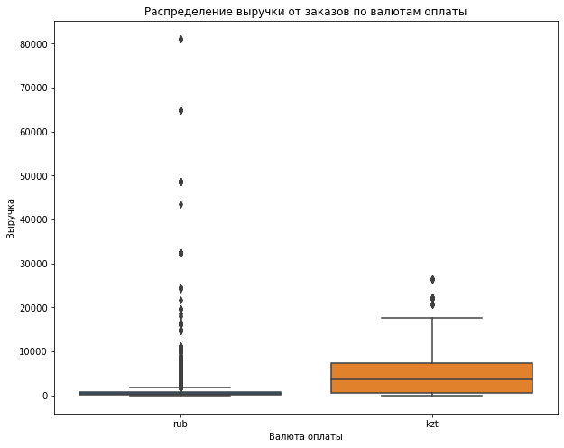

```python
# Создаём контейнер графика matplotlib и задаём его размер
plt.figure(figsize=(10, 8))

# Строим диаграмму размаха для каждого значения currency_code
sns.boxplot(data=df, y='revenue', x='currency_code')

# Добавляем заголовок и метки оси
plt.title(f'Распределение выручки от заказов по валютам оплаты')
plt.xlabel('Валюта оплаты')
plt.ylabel('Выручка')

plt.show()
```

Распределение выручки в российских рублях характеризуется существенным числом выбросов в верхней части гистрограммы, значения выше примерно 10000 рублей можно считать аномальными значениями.  
В распределении выручки в казахстанских тенге также содержатся выбросы, но их существенно меньше.

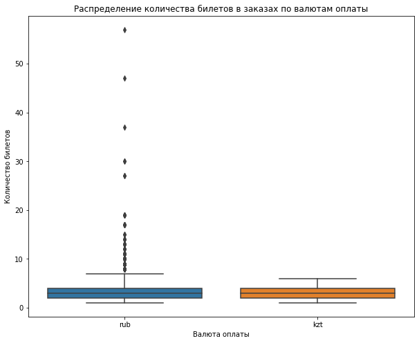

```python
# Создаём контейнер графика matplotlib и задаём его размер
plt.figure(figsize=(10, 8))

# Строим диаграмму размаха для каждого значения currency_code
sns.boxplot(data=df, y='tickets_count', x='currency_code')

# Добавляем заголовок и метки оси
plt.title(f'Распределение количества билетов в заказах по валютам оплаты')
plt.xlabel('Валюта оплаты')
plt.ylabel('Количество билетов')

plt.show()
```

Количество билетов в заказах в российских рублях содержит большое число выбросов после значения 7 билетов. С высокой долей вероятности данные значения можно считать аномальными.  
Распределение количества билетов в заказах в казахстанских тенге выбросов не содержит и находится в пределах от 1 до 6 билетов.

Отберем значения по 99-му процентилю выручки и количества билитов для заказов в российских рублях и по по 99-му процентилю выручки для заказов в казахстанских тенге.

```python
rev_99_rub = df[df['currency_code'] == 'rub']['revenue'].quantile(0.99)
tick_99_rub = df[df['currency_code'] == 'rub']['tickets_count'].quantile(0.99)
rev_99_kzt = df[df['currency_code'] == 'kzt']['revenue'].quantile(0.99)
df = df[((df['currency_code'] == 'rub') & (df['revenue'] <= rev_99_rub) & (df['tickets_count'] <= tick_99_rub)) | \
        ((df['currency_code'] == 'kzt') & (df['revenue'] <= rev_99_kzt))]
```

```python
df[df['currency_code'] == 'rub'][['revenue','tickets_count']].describe()
```

|  | revenue | tickets_count |
| --- | --- | --- |
| count | 282562.000000 | 282562.000000 |
| mean | 510.561628 | 2.735127 |
| std | 500.828305 | 1.136176 |
| min | -90.760000 | 1.000000 |
| 25% | 112.020000 | 2.000000 |
| 50% | 340.490000 | 3.000000 |
| 75% | 781.720000 | 3.000000 |
| max | 2570.800000 | 6.000000 |

В результате удаления аномальных значений статистические показатели по столбцам `revenue` и `tickets_count` в российских рублях стали более сглаженными, но существенная разница между средним и медианным значением выручки всё равно осталась.

```python
df[df['currency_code'] == 'kzt'][['revenue','tickets_count']].describe()
```

|  | revenue | tickets_count |
| --- | --- | --- |
| count | 5040.000000 | 5040.000000 |
| mean | 4893.669063 | 2.748413 |
| std | 4742.680176 | 1.101784 |
| min | 0.000000 | 1.000000 |
| 25% | 515.350000 | 2.000000 |
| 50% | 3698.830000 | 3.000000 |
| 75% | 7397.660000 | 3.000000 |
| max | 17617.240000 | 6.000000 |

Аналогичная ситуация с выручкой в казахстанских тенге — значения сгладились, но среднее и медианное значение существенно отличаются.

Убедимся в корректности данных с курсом.

```python
df['curs'].describe()
```

```
count    287602.000000
mean         19.189011
std           0.622401
min          17.848600
25%          18.599100
50%          19.325600
75%          19.788400
max          20.277300
Name: curs, dtype: float64
```

```python
df['nominal'].describe()
```

```
count    287602.0
mean        100.0
std           0.0
min         100.0
25%         100.0
50%         100.0
75%         100.0
max         100.0
Name: nominal, dtype: float64
```

Значения курса изменяются от 17.848600 до 20.277300, медианное значение практически совпадает со средним. Столбец `nominal` содержит единственное значение 100. Данные корректны.

### 2.3. Проверка явных и неявных дубликатов

Проверим данные на наличие явных и неявных дубликатов. Начнём с полных дубликатов:

```python
df.duplicated().sum()
```

```
0
```

В датафрейме нет полных дубликатов строк. Проверим неявные дубликаты в идентификаторах заказов и в данных по бронированию билета без учёта идентификаторов заказа.

```python
df.duplicated(subset=['order_id']).sum()
```

```
0
```

```python
subs_col = ['user_id', 'created_dt_msk', 'created_ts_msk', 'event_id', 'cinema_circuit', 'age_limit', 'currency_code', \
           'device_type_canonical', 'revenue', 'service_name', 'tickets_count']
df.duplicated(subset=subs_col).sum()
```

```
39
```

Выявлено 39 неявных дубликатов, посмотрим на них.

```python
df[df.duplicated(subset=subs_col, keep=False) == True].sort_values(by=['user_id', 'created_ts_msk', 'revenue'])
```

|  | order_id | user_id | created_dt_msk | created_ts_msk | event_id | cinema_circuit | age_limit | currency_code | device_type_canonical | revenue | service_name | tickets_count | total | days_since_prev | event_name | event_type_description | event_type_main | organizers | region_name | city_name | city_id | venue_id | venue_name | venue_address | data | nominal | curs | cdx |
| --- | --- | --- | --- | --- | --- | --- | --- | --- | --- | --- | --- | --- | --- | --- | --- | --- | --- | --- | --- | --- | --- | --- | --- | --- | --- | --- | --- | --- |
| 11777 | 1123983 | 06eb7897f65b433 | 2024-08-13 | 2024-08-13 16:31:07 | 183706 | нет | 18 | rub | mobile | 69.82 | Билеты в руки | 1 | 997.48 | 0.0 | 69796237-909b-42a7-bfb5-c1b8574c4c76 | спектакль | театр | №1482 | Светополянский округ | Глиноград | 54.0 | 4443.0 | Центр культурного наследия "Объединение" и пар... | бул. Карбышева, д. 50 | 2024-08-13 | 100 | 18.8553 | kzt |
| 11778 | 1123867 | 06eb7897f65b433 | 2024-08-13 | 2024-08-13 16:31:07 | 183706 | нет | 18 | rub | mobile | 69.82 | Билеты в руки | 1 | 997.48 | 0.0 | 69796237-909b-42a7-bfb5-c1b8574c4c76 | спектакль | театр | №1482 | Светополянский округ | Глиноград | 54.0 | 4443.0 | Центр культурного наследия "Объединение" и пар... | бул. Карбышева, д. 50 | 2024-08-13 | 100 | 18.8553 | kzt |
| 26894 | 1930705 | 0dc525d7bacbb0d | 2024-07-31 | 2024-07-31 13:26:11 | 393430 | нет | 18 | rub | desktop | 1556.05 | Лови билет! | 3 | 19450.63 | 11.0 | b33d7a0b-a715-47e3-803e-02482884a73e | концерт | концерты | №5048 | Каменевский регион | Глиногорск | 213.0 | 2704.0 | Летний фестиваль "Симфония" Лтд | бул. Боровой, д. 8/1 стр. 43 | 2024-07-31 | 100 | 18.2404 | kzt |
| 26896 | 1930763 | 0dc525d7bacbb0d | 2024-07-31 | 2024-07-31 13:26:11 | 393430 | нет | 18 | rub | desktop | 1556.05 | Лови билет! | 3 | 19450.63 | 0.0 | b33d7a0b-a715-47e3-803e-02482884a73e | концерт | концерты | №5048 | Каменевский регион | Глиногорск | 213.0 | 2704.0 | Летний фестиваль "Симфония" Лтд | бул. Боровой, д. 8/1 стр. 43 | 2024-07-31 | 100 | 18.2404 | kzt |
| 53715 | 1935113 | 206ea45ec11d478 | 2024-10-29 | 2024-10-29 16:46:54 | 442183 | нет | 16 | rub | mobile | 601.69 | Билеты в руки | 2 | 6016.94 | 32.0 | dcf6f06f-8499-41d7-8bc2-a0e3d7afe313 | концерт | концерты | №894 | Каменевский регион | Глиногорск | 213.0 | 4363.0 | Студия дизайна "Лестница" Лимитед | наб. Школьная, д. 9/8 стр. 7/5 | 2024-10-29 | 100 | 20.0429 | kzt |
| ... | ... | ... | ... | ... | ... | ... | ... | ... | ... | ... | ... | ... | ... | ... | ... | ... | ... | ... | ... | ... | ... | ... | ... | ... | ... | ... | ... | ... |
| 285612 | 8547809 | fd4d47438ebb946 | 2024-06-19 | 2024-06-19 15:40:56 | 489843 | нет | 18 | rub | desktop | 989.57 | Билеты без проблем | 3 | 10995.23 | 0.0 | 25a26bf3-cb70-4f37-a7f0-c97cc065d414 | спектакль | театр | №1858 | Каменевский регион | Глиногорск | 213.0 | 4017.0 | Студия анимации "Точка" Инкорпорэйтед | алл. Тамбовская, д. 7 к. 827 | 2024-06-19 | 100 | 19.2165 | kzt |
| 285619 | 8548099 | fd4d47438ebb946 | 2024-06-19 | 2024-06-19 15:40:56 | 489843 | нет | 18 | rub | desktop | 989.57 | Билеты без проблем | 3 | 10995.23 | 0.0 | 25a26bf3-cb70-4f37-a7f0-c97cc065d414 | спектакль | театр | №1858 | Каменевский регион | Глиногорск | 213.0 | 4017.0 | Студия анимации "Точка" Инкорпорэйтед | алл. Тамбовская, д. 7 к. 827 | 2024-06-19 | 100 | 19.2165 | kzt |
| 285614 | 8547983 | fd4d47438ebb946 | 2024-06-19 | 2024-06-19 15:40:56 | 489843 | нет | 18 | rub | desktop | 1319.43 | Билеты без проблем | 4 | 14660.31 | 0.0 | 25a26bf3-cb70-4f37-a7f0-c97cc065d414 | спектакль | театр | №1858 | Каменевский регион | Глиногорск | 213.0 | 4017.0 | Студия анимации "Точка" Инкорпорэйтед | алл. Тамбовская, д. 7 к. 827 | 2024-06-19 | 100 | 19.2165 | kzt |
| 285615 | 8548012 | fd4d47438ebb946 | 2024-06-19 | 2024-06-19 15:40:56 | 489843 | нет | 18 | rub | desktop | 1319.43 | Билеты без проблем | 4 | 14660.31 | 0.0 | 25a26bf3-cb70-4f37-a7f0-c97cc065d414 | спектакль | театр | №1858 | Каменевский регион | Глиногорск | 213.0 | 4017.0 | Студия анимации "Точка" Инкорпорэйтед | алл. Тамбовская, д. 7 к. 827 | 2024-06-19 | 100 | 19.2165 | kzt |
| 285622 | 8547867 | fd4d47438ebb946 | 2024-06-19 | 2024-06-19 15:40:56 | 489843 | нет | 18 | rub | desktop | 1319.43 | Билеты без проблем | 4 | 14660.31 | 0.0 | 25a26bf3-cb70-4f37-a7f0-c97cc065d414 | спектакль | театр | №1858 | Каменевский регион | Глиногорск | 213.0 | 4017.0 | Студия анимации "Точка" Инкорпорэйтед | алл. Тамбовская, д. 7 к. 827 | 2024-06-19 | 100 | 19.2165 | kzt |

75 rows × 28 columns

Данные строки действительно являются дубликатами, так как различия содержатся только в столбце `order_id`. Удалим их. Также в части строк различается значение в столбце `days_since_prev`, этот столбец пересчитаем позднее, после преобразования типов к датам.

```python
df.drop_duplicates(subset=subs_col, keep='first', inplace=True)
df.info()
```

```
<class 'pandas.core.frame.DataFrame'>
Int64Index: 287563 entries, 0 to 290848
Data columns (total 28 columns):
 #   Column                  Non-Null Count   Dtype
---  ------                  --------------   -----
 0   order_id                287563 non-null  int64
 1   user_id                 287563 non-null  object
 2   created_dt_msk          287563 non-null  object
 3   created_ts_msk          287563 non-null  object
 4   event_id                287563 non-null  int64
 5   cinema_circuit          287563 non-null  object
 6   age_limit               287563 non-null  int64
 7   currency_code           287563 non-null  object
 8   device_type_canonical   287563 non-null  object
 9   revenue                 287563 non-null  float64
```

[output cut: 20 more lines]

### 2.4. Преобразование типов данных

Оптимизируем целочисленный тип данных в столбцах `order_id`, `event_id`, `age_limit`,`tickets_count`,`nominal` и преобразуем дробный тип в целочисленный для `city_id`, `venue_id`.

```python
for column in ['order_id', 'event_id', 'age_limit','tickets_count', 'nominal', 'city_id', 'venue_id']:
    df[column] = pd.to_numeric(df[column], downcast='integer')
```

Понизим разрядность для столбцов с типом данных `float64` до `float32`.

```python
for column in ['revenue', 'total', 'curs']:
    df[column] = pd.to_numeric(df[column], downcast='float')
```

Обработаем типы данных в столбцах, которые хранят значения даты и времени.

```python
for column in ['created_dt_msk', 'created_ts_msk', 'data']:
    df[column] = pd.to_datetime(df[column])
```

Пересчитаем столбец `days_since_prev` и приведем его к целочисленному типу.

```python
df = df.sort_values(['user_id', 'created_ts_msk'])
df['days_since_prev'] = (df['created_dt_msk'] - df.groupby('user_id')['created_dt_msk'].shift(1)).dt.days
df['days_since_prev'] = pd.to_numeric(df['days_since_prev'].fillna(-1), downcast='integer')
```

```python
df.dtypes
```

```
order_id                           int32
user_id                           object
created_dt_msk            datetime64[ns]
created_ts_msk            datetime64[ns]
event_id                           int32
cinema_circuit                    object
age_limit                           int8
currency_code                     object
device_type_canonical             object
revenue                          float32
service_name                      object
tickets_count                       int8
total                            float32
days_since_prev                    int16
event_name                        object
event_type_description            object
event_type_main                   object
organizers                        object
region_name                       object
city_name                         object
city_id                            int32
venue_id                           int16
venue_name                        object
venue_address                     object
data                      datetime64[ns]
nominal                             int8
curs                             float32
cdx                               object
dtype: object
```

### 2.5. Создание новых столбцов

Приведем выручку с заказа к единой валюте — российскому рублю.

```python
df['revenue_rub'] = df['revenue']
mask_kzt = df['currency_code'] == 'kzt'
df.loc[mask_kzt,'revenue_rub'] = df.loc[mask_kzt,'revenue'] * df.loc[mask_kzt,'curs'] / df.loc[mask_kzt,'nominal']
```

Рассчитаем выручку с продажи одного билета на мероприятие.

```python
df['one_ticket_revenue_rub'] = df['revenue_rub'] / df['tickets_count']
```

Рассчитаем стоимость одного билета на мероприятие.

```python
df['one_ticket_cost'] = df['total'] / df['tickets_count']
df.loc[mask_kzt,'one_ticket_cost'] = df.loc[mask_kzt,'one_ticket_cost'] * df.loc[mask_kzt,'curs'] / df.loc[mask_kzt,'nominal']

# Удалим ненужные столбцы из таблицы final_tickets_tenge_df.csv
df = df.drop(columns=['curs', 'nominal', 'data', 'cdx'])
```

Выделим месяц оформления заказа в отдельный столбец.

```python
df['month'] = df['created_dt_msk'].dt.month
df['month'] = pd.to_numeric(df['month'], downcast='integer')
```

Создадим столбец с информацией о сезонности, включая такие категории, как: 'лето', 'осень', 'зима', 'весна'.

```python
def calc_season(month):
    if month in [12, 1, 2]:
        return 'зима'
    elif month in [3, 4, 5]:
        return 'весна'
    elif month in [6, 7, 8]:
        return 'лето'
    else:
        return 'осень'
```

```python
df['season'] = df['month'].apply(calc_season)
```

```python
df.head()
```

|  | order_id | user_id | created_dt_msk | created_ts_msk | event_id | cinema_circuit | age_limit | currency_code | device_type_canonical | revenue | service_name | tickets_count | total | days_since_prev | event_name | event_type_description | event_type_main | organizers | region_name | city_name | city_id | venue_id | venue_name | venue_address | revenue_rub | one_ticket_revenue_rub | one_ticket_cost | month | season |
| --- | --- | --- | --- | --- | --- | --- | --- | --- | --- | --- | --- | --- | --- | --- | --- | --- | --- | --- | --- | --- | --- | --- | --- | --- | --- | --- | --- | --- | --- |
| 0 | 4359165 | 0002849b70a3ce2 | 2024-08-20 | 2024-08-20 16:08:03 | 169230 | нет | 16 | rub | mobile | 1521.939941 | Край билетов | 4 | 10870.990234 | -1 | f0f7b271-04eb-4af6-bcb8-8f05cf46d6ad | спектакль | театр | №3322 | Каменевский регион | Глиногорск | 213 | 3972 | Сценический центр "Деталь" Групп | алл. Машиностроителей, д. 19 стр. 6 | 1521.939941 | 380.484985 | 2717.747559 | 8 | лето |
| 1 | 7965605 | 0005ca5e93f2cf4 | 2024-07-23 | 2024-07-23 18:36:24 | 237325 | нет | 0 | rub | mobile | 289.450012 | Мой билет | 2 | 2067.510010 | -1 | 40efeb04-81b7-4135-b41f-708ff00cc64c | событие | выставки | №4850 | Каменевский регион | Глиногорск | 213 | 2941 | Музыкальная школа для детей "Аккаунт" Лтд | алл. Шмидта, д. 9 стр. 4 | 289.450012 | 144.725006 | 1033.755005 | 7 | лето |
| 2 | 7292370 | 0005ca5e93f2cf4 | 2024-10-06 | 2024-10-06 13:56:02 | 578454 | нет | 0 | rub | mobile | 1258.569946 | За билетом! | 4 | 13984.160156 | 75 | 01f3fb7b-ed07-4f94-b1d3-9a2e1ee5a8ca | цирковое шоу | другое | №1540 | Каменевский регион | Глиногорск | 213 | 4507 | Училище искусств "Нирвана" Инк | алл. Юбилейная, д. 5/6 | 1258.569946 | 314.642487 | 3496.040039 | 10 | осень |
| 3 | 1139875 | 000898990054619 | 2024-07-13 | 2024-07-13 19:40:48 | 387271 | нет | 0 | rub | mobile | 8.490000 | Лови билет! | 2 | 212.279999 | -1 | 2f638715-8844-466c-b43f-378a627c419f | выставка | другое | №5049 | Североярская область | Озёрск | 2 | 3574 | Театр альтернативного искусства "Ода" Лимитед | алл. Есенина, д. 243 к. 3/8 | 8.490000 | 4.245000 | 106.139999 | 7 | лето |
| 4 | 972400 | 000898990054619 | 2024-10-04 | 2024-10-04 22:33:15 | 509453 | нет | 18 | rub | mobile | 1390.410034 | Билеты без проблем | 3 | 10695.429688 | 83 | 10d805d3-9809-4d8a-834e-225b7d03f95d | шоу | стендап | №832 | Озернинский край | Родниковецк | 240 | 1896 | Театр кукол "Огни" Инкорпорэйтед | ш. Набережное, д. 595 стр. 8 | 1390.410034 | 463.470001 | 3565.143311 | 10 | осень |

```python
df.info()
```

```
<class 'pandas.core.frame.DataFrame'>
Int64Index: 287563 entries, 0 to 290848
Data columns (total 29 columns):
 #   Column                  Non-Null Count   Dtype
---  ------                  --------------   -----
 0   order_id                287563 non-null  int32
 1   user_id                 287563 non-null  object
 2   created_dt_msk          287563 non-null  datetime64[ns]
 3   created_ts_msk          287563 non-null  datetime64[ns]
 4   event_id                287563 non-null  int32
 5   cinema_circuit          287563 non-null  object
 6   age_limit               287563 non-null  int8
 7   currency_code           287563 non-null  object
 8   device_type_canonical   287563 non-null  object
 9   revenue                 287563 non-null  float32
```

[output cut: 21 more lines]

```python
# Подсчитаем число строк в датафрейме после предобработки
fin_row_count = df.shape[0]
del_row_count = init_row_count - fin_row_count
del_row_count
```

```
3286
```

```python
# Процент удаленных строк
round(del_row_count / init_row_count * 100, 2)
```

```
1.13
```

#### Промежуточный вывод

В результате предобработки данных в объединенном датафрейме `df` были выполнены следующие действия:

## 3. Исследовательский анализ данных

### 3.1. Анализ распределения заказов по сегментам и их сезонные изменения

Изучим изменение пользовательской активности или пользовательского интереса в связи с сезонностью. Проанализиеруем динамику по таким разрезам:

- тип мероприятия `event_type_main`;
- тип устройства `device_type_canonical`;
- категория мероприятий по возрастному рейтингу `age_limit`.

Для каждого месяца найдем количество заказов и визуализируем результат.

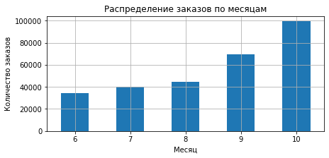

```python
grouped = df.groupby('month')['order_id'].count()

plt.figure(figsize=(7, 3))
grouped.plot(kind='bar', rot=0, legend=False, title=f'Распределение заказов по месяцам')

plt.xlabel('Месяц')
plt.ylabel('Количество заказов')
plt.grid()

plt.show()
```

В период с июня по октябрь 2024 года наблюдается стабильный рост количества заказов.

Для осеннего и летнего периодов сравним распределение заказов билетов по разным категориям: тип мероприятия, тип устройства, категория мероприятия по возрастному рейтингу.

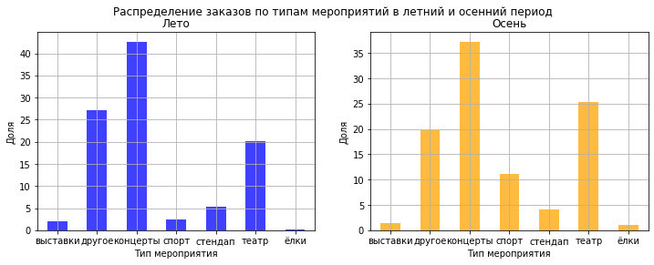

```python
event_summer = df[df['season']=='лето'].groupby('event_type_main')['order_id'].count() * 100 / \
    df[df['season']=='лето']['order_id'].count()
event_autumn = df[df['season']=='осень'].groupby('event_type_main')['order_id'].count() * 100 / \
    df[df['season']=='осень']['order_id'].count()

fig, (ax1, ax2) = plt.subplots(1, 2, figsize=(12, 4))

event_summer.plot(kind='bar', rot=0, alpha=0.75, color='blue', ax=ax1)
ax1.set_xlabel('Тип мероприятия')
ax1.set_ylabel('Доля')
ax1.set_title('Лето')
ax1.grid()

event_autumn.plot(kind='bar', rot=0, alpha=0.75, color='orange', ax=ax2)
ax2.set_xlabel('Тип мероприятия')
ax2.set_ylabel('Доля')
ax2.set_title('Осень')
ax2.grid()

fig.suptitle('Распределение заказов по типам мероприятий в летний и осенний период')
plt.show()
```

Основную долю заказов и в летний, и в осенний период составляют концерты, но осенью наблюдается снижение с ~42.5% до ~37.5%.  
В осенний период растёт доля театров с ~20% до ~25%, что может объясняться началом театрального сезона, а также завершением школьных каникул и сезона отпусков. Также осенью отмечается рост доли спортивных мероприятий c ~2.5% до ~11%, что может быть связано с началом спортивных состязаний.

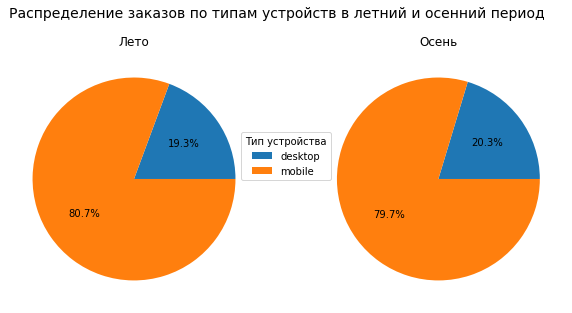

```python
device_summer = df[df['season']=='лето'].groupby('device_type_canonical')['order_id'].count() * 100 / \
    df[df['season']=='лето']['order_id'].count()
device_autumn = df[df['season']=='осень'].groupby('device_type_canonical')['order_id'].count() * 100 / \
    df[df['season']=='осень']['order_id'].count()

labels = device_summer.index
fig, (ax1, ax2) = plt.subplots(1, 2, figsize=(10, 5))

ax1.pie(device_summer, autopct='%1.1f%%')
ax1.set_title('Лето')

ax2.pie(device_autumn, autopct='%1.1f%%')
ax2.set_title('Осень')

fig.legend(labels, loc='center', title='Тип устройства')
fig.suptitle('Распределение заказов по типам устройств в летний и осенний период', fontsize=14)

plt.show()
```

Независимо от сезона преобладающим типом устройств для оформления заказов являются мобильные, при этом осенью наблюдается незначительное снижение (на 1%).

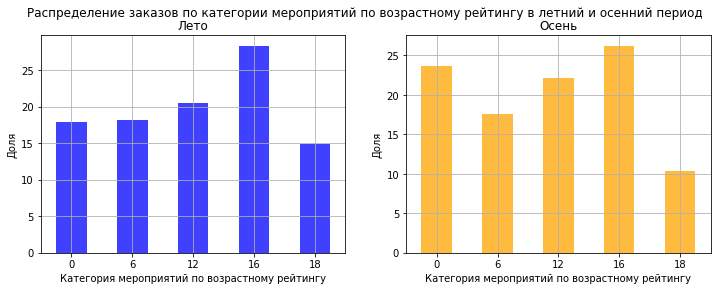

```python
age_summer = df[df['season']=='лето'].groupby('age_limit')['order_id'].count() * 100 / \
    df[df['season']=='лето']['order_id'].count()
age_autumn = df[df['season']=='осень'].groupby('age_limit')['order_id'].count() * 100 / \
    df[df['season']=='осень']['order_id'].count()

fig, (ax1, ax2) = plt.subplots(1, 2, figsize=(12, 4))

age_summer.plot(kind='bar', rot=0, alpha=0.75, color='blue', ax=ax1)
ax1.set_xlabel('Категория мероприятий по возрастному рейтингу')
ax1.set_ylabel('Доля')
ax1.set_title('Лето')
ax1.grid()

age_autumn.plot(kind='bar', rot=0, alpha=0.75, color='orange', ax=ax2)
ax2.set_xlabel('Категория мероприятий по возрастному рейтингу')
ax2.set_ylabel('Доля')
ax2.set_title('Осень')
ax2.grid()

fig.suptitle('Распределение заказов по категории мероприятий по возрастному рейтингу в летний и осенний период')
plt.show()
```

В летний период наиболее популярными являются мероприятия с возрастным ограничением "16+", осенью эта категория остается самой популярной, хотя и отмечается назначительное снижение, но при этом наблюдается рост доли мероприятий без возрастных ограничений "0+" с ~18% до ~24%. Это может быть связано с увеличением числа детских мероприятий, а также началом сезона продажи билетов на новогодние праздники.

Изучим изменение выручки с продажи одного билета в зависимости от типа мероприятия летом и осенью.

```python
df_agg = df.groupby(['season', 'event_type_main'])['one_ticket_revenue_rub'].mean().reset_index()

df_pivot = df_agg.pivot(index='event_type_main', columns='season', values='one_ticket_revenue_rub')
df_pivot['change'] = round((df_pivot['осень'] - df_pivot['лето']) * 100 / df_pivot['лето'], 2)
df_pivot
```

| season event_type_main | лето | осень | change |
| --- | --- | --- | --- |
| выставки | 86.416199 | 90.603607 | 4.85 |
| другое | 77.395256 | 76.059692 | -1.73 |
| концерты | 304.800049 | 268.379913 | -11.95 |
| спорт | 50.744648 | 49.986591 | -1.49 |
| стендап | 218.518112 | 231.124969 | 5.77 |
| театр | 214.179489 | 175.991608 | -17.83 |
| ёлки | 271.436188 | 229.564209 | -15.43 |

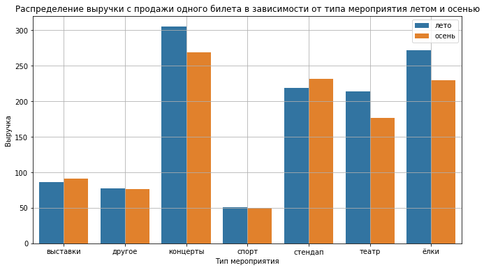

```python
plt.figure(figsize=(11,6))

sns.barplot(data = df_agg, x='event_type_main', y='one_ticket_revenue_rub', hue='season')

plt.title('Распределение выручки с продажи одного билета в зависимости от типа мероприятия летом и осенью')
plt.legend()
plt.xlabel('Тип мероприятия')
plt.ylabel('Выручка')
plt.grid()

plt.show()
```

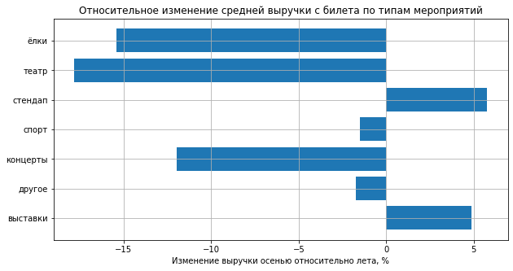

```python
plt.figure(figsize=(10,5))

plt.barh(df_pivot.index, df_pivot['change'])
plt.title('Относительное изменение средней выручки с билета по типам мероприятий')
plt.xlabel('Изменение выручки осенью относительно лета, %')
plt.grid()

plt.show()
```

Осенью наблюдается снижение средней выручки с одного билета практически по всем типам мероприятий, наиболее существенное снижение: театры (на 17.83%), ёлки (на 15.43%), концерты (на 11.95%). При этом для двух типов мероприятий, напротов, отмечается рост выручки с одного билета — это стендап (на 5.77%) и выставки (на 4.85%).

#### Промежуточный вывод

Таким образом, наблюдается влияние сезонности на количество заказов и выручку с одного билета. При этом влияние разнонаправленное: количество заказов растет, а выручка с одного билета — падает.

### 3.2. Осенняя активность пользователей

Изучим активность пользователей осенью 2024 года.

Проанализируем динамику изменений по дням для:

- общего числа заказов;
- количества активных пользователей DAU;
- среднего числа заказов на одного пользователя;
- средней стоимости одного билета.

```python
autumn = df[df['season']=='осень'].copy()

autumn_pivot = pd.pivot_table(autumn, values = ['order_id', 'user_id', 'one_ticket_cost'], index='created_dt_msk',
               aggfunc={'order_id': 'count', 'user_id': 'nunique', 'one_ticket_cost': 'mean'}).reset_index()
autumn_pivot['orders_per_user'] = round(autumn_pivot['order_id'] / autumn_pivot['user_id'], 2)
autumn_pivot = autumn_pivot.rename(columns={'created_dt_msk': 'date',
                             'order_id': 'orders_count',
                             'user_id': 'users_count',
                             'one_ticket_cost': 'cost_mean'})
autumn_pivot.head()
```

|  | date | cost_mean | orders_count | users_count | orders_per_user |
| --- | --- | --- | --- | --- | --- |
| 0 | 2024-09-01 | 2290.044189 | 1327 | 564 | 2.35 |
| 1 | 2024-09-02 | 2192.251953 | 1380 | 574 | 2.40 |
| 2 | 2024-09-03 | 1295.991821 | 5113 | 778 | 6.57 |
| 3 | 2024-09-04 | 2157.451660 | 1772 | 685 | 2.59 |
| 4 | 2024-09-05 | 2193.372559 | 1940 | 739 | 2.63 |

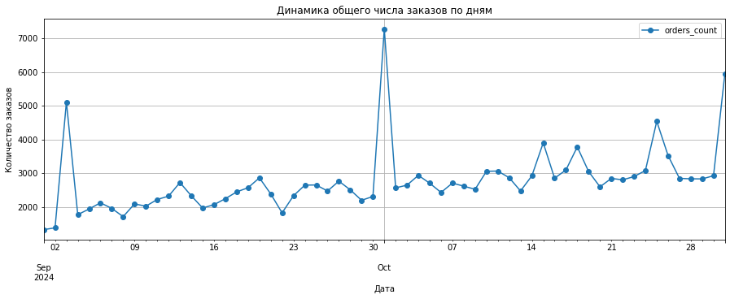

```python
autumn_pivot.plot(kind='line', x='date', y='orders_count', marker='o', figsize=(15,5))

plt.title('Динамика общего числа заказов по дням')
plt.xlabel('Дата')
plt.ylabel('Количество заказов')
plt.grid()

plt.show()
```

Изменение общего числа заказов имеет положительную динамику с несколькими пиками в начале месяца (3 сентября и 1 октября) и в конце октября (25 и 31). В остальные дни колебания показателя незначительные.

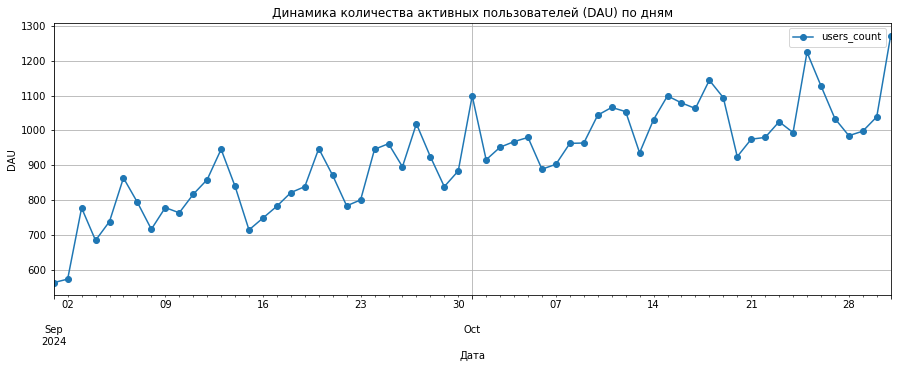

```python
autumn_pivot.plot(kind='line', x='date', y='users_count', marker='o', figsize=(15,5))

plt.title('Динамика количества активных пользователей (DAU) по дням')
plt.xlabel('Дата')
plt.ylabel('DAU')
plt.grid()

plt.show()
```

Изменение количества активных пользователей также имеет положительную динамику, однако характеризуется бОльшими колебаниями. При этом пиковые значения также приходятся на 1, 25 и 31 октября.  
За весь рассмтариваемый период количество активных пользователей существенно возросло: с ~570 человек 1 сентября до ~1280 человек 31 октября.

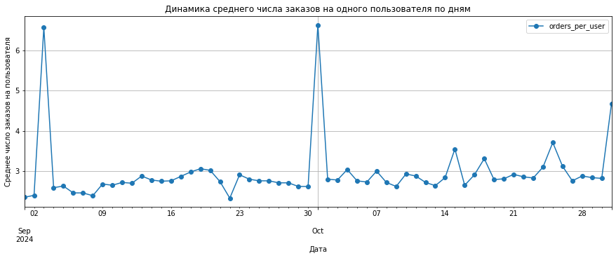

```python
autumn_pivot.plot(kind='line', x='date', y='orders_per_user', marker='o', figsize=(15,5))

plt.title('Динамика среднего числа заказов на одного пользователя по дням')
plt.xlabel('Дата')
plt.ylabel('Среднее число заказов на пользователя')
plt.grid()

plt.show()
```

Для среднего числа заказов на одного пользователя не наблюдается явной тенденции к росту и снижению, колебания показателя незначительные, однако присутствуют всплески в начале месяца (3 сентября и 1 октября) и в конце октября (25 и 31), совпадающие с пиковыми периодами общего числа заказов и количества активных пользователей.

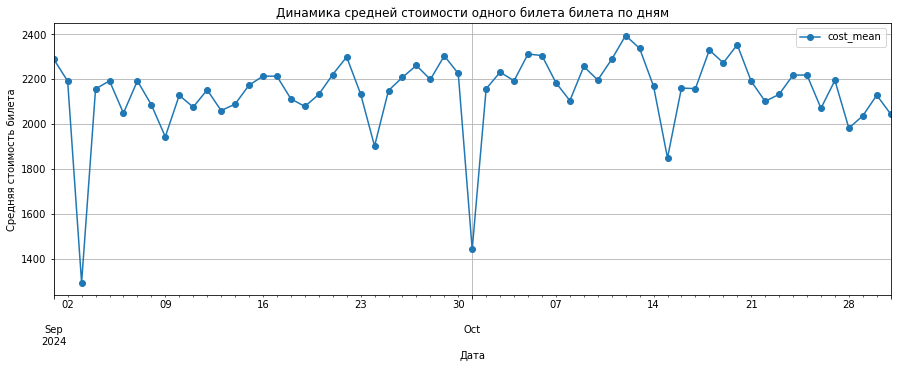

```python
autumn_pivot.plot(kind='line', x='date', y='cost_mean', marker='o', figsize=(15,5))

plt.title('Динамика средней стоимости одного билета билета по дням')
plt.xlabel('Дата')
plt.ylabel('Средняя стоимость билета')
plt.grid()

plt.show()
```

Средняя стоимость одного билета подвержена колебаниям, тенденция к росту или снижению не прослеживается. При этом можно отметить значительные спады в начале месяца (3 сентября и 1 октября) и 15. В эти же периоды отмечались всплески среднего числа заказов на одного пользователя, что может как раз объясняться снижением цен на билеты.

Изучим недельную цикличность и сравним пользовательскую активность в будни и выходные.

```python
autumn['day_of_week'] = autumn['created_dt_msk'].dt.day_of_week + 1

calendar_range = pd.date_range(start=autumn['created_dt_msk'].min(), end=autumn['created_dt_msk'].max(), freq='D')
days_in_period = (pd.Series(calendar_range).dt.dayofweek + 1).value_counts().sort_index()
```

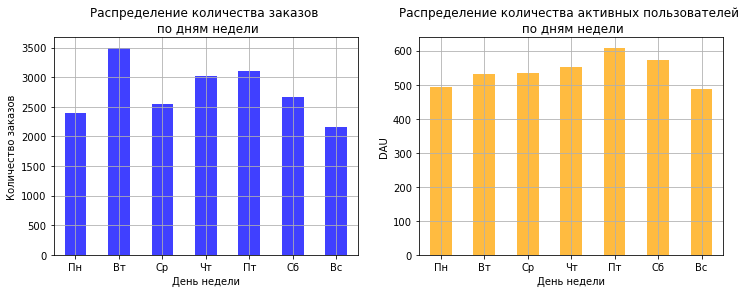

```python
grouped_orders = autumn.groupby('day_of_week')['order_id'].count()
grouped_users = autumn.groupby('day_of_week')['user_id'].nunique()

# Нормализуем: вычислим среднее значение на одно вхождение дня
avg_orders = grouped_orders / days_in_period
avg_users = grouped_users / days_in_period

fig, (ax1, ax2) = plt.subplots(1, 2, figsize=(12, 4))

avg_orders.plot(kind='bar', rot=0, alpha=0.75, color='blue', ax=ax1)
ax1.set_xlabel('День недели')
ax1.set_ylabel('Количество заказов')
ax1.set_title('Распределение количества заказов \n по дням недели')
ax1.set_xticklabels(['Пн', 'Вт', 'Ср', 'Чт', 'Пт', 'Сб', 'Вс'])
ax1.grid()

avg_users.plot(kind='bar', rot=0, alpha=0.75, color='orange', ax=ax2)
ax2.set_xlabel('День недели')
ax2.set_ylabel('DAU')
ax2.set_title('Распределение количества активных пользователей \n по дням недели')
ax2.set_xticklabels(['Пн', 'Вт', 'Ср', 'Чт', 'Пт', 'Сб', 'Вс'])
ax2.grid()

plt.show()
```

Наибольшее количество заказов приходится на вторник, четверг и пятницу, к выходным наблюдается спад заказов. Количество активных пользователей растет с понедельника по пятницу, к выходным также снижаясь. Такое поведение можно объяснить тем, что мероприятия в основном проводятся с пятницы по воскресенье и пользователи планируют свой досуг в середине недели.

#### Промежуточный вывод

- Общее число заказов растет с небольшими колебаниями и несколькими пиками в начале месяца (3 сентября и 1 октября) и в конце октября (25 и 31).
- Количество активных пользователей также растет, однако характеризуется бОльшими колебаниями. Пиковые значения также приходятся на 1, 25 и 31 октября.
- Среднее число заказов на одного пользователя незначительно колеблется без явной тенденции к росту и снижению, также присутствуют пики в начале месяца (3 сентября и 1 октября) и в конце октября (25 и 31).
- Средняя стоимость одного билета подвержена колебаниям без явной тенденции к росту и снижению. При этом можно присутствуют значительные спады в начале месяца (3 сентября и 1 октября).
- Видна взаимосвязь этих четрых показателей: пиковые значения количества заказов, активных пользователей и заказов на одного пользователя практически совпадают с резкими спадами средней стоимости одного билета.
- Анализ недельной динамики показал, что наибольшее количество заказов приходится на вторник, четверг и пятницу, количество активных пользователей растет с понедельника по пятницу, к концу недели отмечается снижение обоих показателей. Это можно объяснить проведением мероприятий в основном с пятницы по воскресенье и планированием пользователями своего досуга в середине недели.

### 3.3. Популярные события и партнёры

Посмотрим, как события распределены по регионам и партнёрам. Это позволит выделить ключевые регионы и партнёров, которые вносят наибольший вклад в выручку.

Для каждого региона посчитаем уникальное количество мероприятий и общее число заказов.

```python
df_pivot = pd.pivot_table(df, values = ['order_id', 'event_name'], index='region_name',
               aggfunc={'order_id': 'count', 'event_name': 'nunique'}).reset_index()
df_pivot['orders_part'] = round(100 * df_pivot['order_id'] / df_pivot['order_id'].sum(), 3)
df_pivot['events_part'] = round(100 * df_pivot['event_name'] / df_pivot['event_name'].sum(), 3)
df_pivot = df_pivot.rename(columns={'region_name': 'region',
                             'order_id': 'orders_count',
                             'event_name': 'events_count'})
df_pivot = df_pivot.sort_values(by='events_count', ascending=False)
df_pivot
```

|  | region | events_count | orders_count | orders_part | events_part |
| --- | --- | --- | --- | --- | --- |
| 23 | Каменевский регион | 4748 | 89637 | 31.171 | 24.781 |
| 60 | Североярская область | 3196 | 43621 | 15.169 | 16.681 |
| 57 | Светополянский округ | 997 | 7500 | 2.608 | 5.204 |
| 77 | Широковская область | 992 | 16164 | 5.621 | 5.177 |
| 52 | Речиновская область | 653 | 6265 | 2.179 | 3.408 |
| ... | ... | ... | ... | ... | ... |
| 68 | Теплоозёрский округ | 2 | 7 | 0.002 | 0.010 |
| 66 | Сосноводолинская область | 2 | 10 | 0.003 | 0.010 |
| 33 | Лесноярский край | 2 | 19 | 0.007 | 0.010 |
| 56 | Светолесский край | 2 | 24 | 0.008 | 0.010 |
| 5 | Верхозёрский край | 2 | 11 | 0.004 | 0.010 |

81 rows × 5 columns

```python
df_pivot = df_pivot.sort_values(by='orders_count', ascending=False)
df_pivot
```

|  | region | events_count | orders_count | orders_part | events_part |
| --- | --- | --- | --- | --- | --- |
| 23 | Каменевский регион | 4748 | 89637 | 31.171 | 24.781 |
| 60 | Североярская область | 3196 | 43621 | 15.169 | 16.681 |
| 77 | Широковская область | 992 | 16164 | 5.621 | 5.177 |
| 42 | Медовская область | 485 | 13890 | 4.830 | 2.531 |
| 45 | Озернинский край | 307 | 10403 | 3.618 | 1.602 |
| ... | ... | ... | ... | ... | ... |
| 33 | Лесноярский край | 2 | 19 | 0.007 | 0.010 |
| 32 | Крутоводский регион | 7 | 18 | 0.006 | 0.037 |
| 5 | Верхозёрский край | 2 | 11 | 0.004 | 0.010 |
| 66 | Сосноводолинская область | 2 | 10 | 0.003 | 0.010 |
| 68 | Теплоозёрский округ | 2 | 7 | 0.002 | 0.010 |

81 rows × 5 columns

Среди регионов есть явные лидеры по уникальному количеству мероприятий и общему числу заказов — это Каменевский регион и Североярская область, на долю которых приходится ~40% всех мероприятий и ~46% всех заказов. Доля остальных регионов существенно ниже и не превышает 6% у каждого.

Для каждого билетного партнёра посчитаем общее число уникальных мероприятий, обработанных заказов и суммарную выручку с заказов билетов.

```python
df_pivot = pd.pivot_table(df, values = ['order_id', 'event_name', 'revenue_rub'], index='service_name',
               aggfunc={'order_id': 'count', 'event_name': 'nunique', 'revenue_rub': 'sum'}).reset_index()
df_pivot['orders_part'] = round(100 * df_pivot['order_id'] / df_pivot['order_id'].sum(), 2)
df_pivot['events_part'] = round(100 * df_pivot['event_name'] / df_pivot['event_name'].sum(), 2)
df_pivot['revenue_part'] = round(100 * df_pivot['revenue_rub'] / df_pivot['revenue_rub'].sum(), 2)
df_pivot = df_pivot.rename(columns={'order_id': 'orders_count',
                             'event_name': 'events_count',
                             'revenue_rub': 'revenue'})
df_pivot = df_pivot.sort_values(by='events_count', ascending=False)
df_pivot.style.format({'revenue': '{:.2f}', 'orders_part': '{:.2f}', 'events_part': '{:.2f}', 'revenue_part': '{:.2f}'})
```

|  | service_name | events_count | orders_count | revenue | orders_part | events_part | revenue_part |
| --- | --- | --- | --- | --- | --- | --- | --- |
| 21 | Лови билет! | 3856 | 40796 | 16673025.00 | 14.19 | 19.43 | 11.18 |
| 3 | Билеты без проблем | 3156 | 62723 | 24195254.00 | 21.81 | 15.90 | 16.23 |
| 5 | Билеты в руки | 2942 | 40272 | 13191080.00 | 14.00 | 14.82 | 8.85 |
| 25 | Облачко | 1762 | 26402 | 18588614.00 | 9.18 | 8.88 | 12.47 |
| 22 | Лучшие билеты | 1514 | 17732 | 2720706.50 | 6.17 | 7.63 | 1.82 |
| 24 | Мой билет | 1029 | 34413 | 22016176.00 | 11.97 | 5.18 | 14.77 |
| 30 | Тебе билет! | 925 | 5190 | 2962303.00 | 1.80 | 4.66 | 1.99 |
| 26 | Прачечная | 874 | 10222 | 4746810.50 | 3.55 | 4.40 | 3.18 |
| 8 | Весь в билетах | 688 | 16424 | 16532347.00 | 5.71 | 3.47 | 11.09 |
| 35 | Яблоко | 612 | 5004 | 3868337.00 | 1.74 | 3.08 | 2.59 |
| 12 | Городской дом культуры | 350 | 2727 | 1641318.38 | 0.95 | 1.76 | 1.10 |
| 1 | Show_ticket | 267 | 2090 | 1449276.38 | 0.73 | 1.35 | 0.97 |
| 0 | Crazy ticket! | 247 | 789 | 451924.81 | 0.27 | 1.24 | 0.30 |
| 19 | Край билетов | 233 | 6108 | 6403469.00 | 2.12 | 1.17 | 4.29 |
| 13 | Дом культуры | 231 | 4412 | 4358656.00 | 1.53 | 1.16 | 2.92 |
| 15 | За билетом! | 227 | 2854 | 2035900.12 | 0.99 | 1.14 | 1.37 |
| 6 | Быстробилет | 225 | 1982 | 1532847.00 | 0.69 | 1.13 | 1.03 |
| 23 | Мир касс | 183 | 2137 | 1837646.88 | 0.74 | 0.92 | 1.23 |
| 9 | Восьмёрка | 141 | 1106 | 657809.25 | 0.38 | 0.71 | 0.44 |
| 11 | Выступления.ру | 135 | 1590 | 1218604.75 | 0.55 | 0.68 | 0.82 |
| 29 | Росбилет | 59 | 395 | 514513.38 | 0.14 | 0.30 | 0.35 |
| 17 | КарандашРУ | 46 | 133 | 24472.86 | 0.05 | 0.23 | 0.02 |
| 10 | Вперёд! | 37 | 80 | 31539.65 | 0.03 | 0.19 | 0.02 |
| 31 | Телебилет | 23 | 321 | 187322.66 | 0.11 | 0.12 | 0.13 |
| 33 | Цвет и билет | 18 | 61 | 51403.09 | 0.02 | 0.09 | 0.03 |
| 2 | Билет по телефону | 17 | 85 | 72447.40 | 0.03 | 0.09 | 0.05 |
| 7 | Быстрый кассир | 16 | 379 | 396689.94 | 0.13 | 0.08 | 0.27 |
| 34 | Шоу начинается! | 9 | 460 | 463641.19 | 0.16 | 0.05 | 0.31 |
| 27 | Радио ticket | 8 | 376 | 81893.24 | 0.13 | 0.04 | 0.05 |
| 28 | Реестр | 7 | 124 | 55136.92 | 0.04 | 0.04 | 0.04 |
| 20 | Лимоны | 3 | 8 | 636.51 | 0.00 | 0.02 | 0.00 |
| 14 | Дырокол | 2 | 70 | 104077.95 | 0.02 | 0.01 | 0.07 |
| 32 | Тех билет | 2 | 22 | 5665.74 | 0.01 | 0.01 | 0.00 |
| 4 | Билеты в интернете | 1 | 4 | 548.23 | 0.00 | 0.01 | 0.00 |
| 16 | Зе Бест! | 1 | 5 | 64.30 | 0.00 | 0.01 | 0.00 |
| 18 | Кино билет | 1 | 67 | 21808.64 | 0.02 | 0.01 | 0.01 |

```python
df_pivot = df_pivot.sort_values(by='orders_count', ascending=False)
df_pivot.style.format({'revenue': '{:.2f}', 'orders_part': '{:.2f}', 'events_part': '{:.2f}', 'revenue_part': '{:.2f}'})
```

|  | service_name | events_count | orders_count | revenue | orders_part | events_part | revenue_part |
| --- | --- | --- | --- | --- | --- | --- | --- |
| 3 | Билеты без проблем | 3156 | 62723 | 24195254.00 | 21.81 | 15.90 | 16.23 |
| 21 | Лови билет! | 3856 | 40796 | 16673025.00 | 14.19 | 19.43 | 11.18 |
| 5 | Билеты в руки | 2942 | 40272 | 13191080.00 | 14.00 | 14.82 | 8.85 |
| 24 | Мой билет | 1029 | 34413 | 22016176.00 | 11.97 | 5.18 | 14.77 |
| 25 | Облачко | 1762 | 26402 | 18588614.00 | 9.18 | 8.88 | 12.47 |
| 22 | Лучшие билеты | 1514 | 17732 | 2720706.50 | 6.17 | 7.63 | 1.82 |
| 8 | Весь в билетах | 688 | 16424 | 16532347.00 | 5.71 | 3.47 | 11.09 |
| 26 | Прачечная | 874 | 10222 | 4746810.50 | 3.55 | 4.40 | 3.18 |
| 19 | Край билетов | 233 | 6108 | 6403469.00 | 2.12 | 1.17 | 4.29 |
| 30 | Тебе билет! | 925 | 5190 | 2962303.00 | 1.80 | 4.66 | 1.99 |
| 35 | Яблоко | 612 | 5004 | 3868337.00 | 1.74 | 3.08 | 2.59 |
| 13 | Дом культуры | 231 | 4412 | 4358656.00 | 1.53 | 1.16 | 2.92 |
| 15 | За билетом! | 227 | 2854 | 2035900.12 | 0.99 | 1.14 | 1.37 |
| 12 | Городской дом культуры | 350 | 2727 | 1641318.38 | 0.95 | 1.76 | 1.10 |
| 23 | Мир касс | 183 | 2137 | 1837646.88 | 0.74 | 0.92 | 1.23 |
| 1 | Show_ticket | 267 | 2090 | 1449276.38 | 0.73 | 1.35 | 0.97 |
| 6 | Быстробилет | 225 | 1982 | 1532847.00 | 0.69 | 1.13 | 1.03 |
| 11 | Выступления.ру | 135 | 1590 | 1218604.75 | 0.55 | 0.68 | 0.82 |
| 9 | Восьмёрка | 141 | 1106 | 657809.25 | 0.38 | 0.71 | 0.44 |
| 0 | Crazy ticket! | 247 | 789 | 451924.81 | 0.27 | 1.24 | 0.30 |
| 34 | Шоу начинается! | 9 | 460 | 463641.19 | 0.16 | 0.05 | 0.31 |
| 29 | Росбилет | 59 | 395 | 514513.38 | 0.14 | 0.30 | 0.35 |
| 7 | Быстрый кассир | 16 | 379 | 396689.94 | 0.13 | 0.08 | 0.27 |
| 27 | Радио ticket | 8 | 376 | 81893.24 | 0.13 | 0.04 | 0.05 |
| 31 | Телебилет | 23 | 321 | 187322.66 | 0.11 | 0.12 | 0.13 |
| 17 | КарандашРУ | 46 | 133 | 24472.86 | 0.05 | 0.23 | 0.02 |
| 28 | Реестр | 7 | 124 | 55136.92 | 0.04 | 0.04 | 0.04 |
| 2 | Билет по телефону | 17 | 85 | 72447.40 | 0.03 | 0.09 | 0.05 |
| 10 | Вперёд! | 37 | 80 | 31539.65 | 0.03 | 0.19 | 0.02 |
| 14 | Дырокол | 2 | 70 | 104077.95 | 0.02 | 0.01 | 0.07 |
| 18 | Кино билет | 1 | 67 | 21808.64 | 0.02 | 0.01 | 0.01 |
| 33 | Цвет и билет | 18 | 61 | 51403.09 | 0.02 | 0.09 | 0.03 |
| 32 | Тех билет | 2 | 22 | 5665.74 | 0.01 | 0.01 | 0.00 |
| 20 | Лимоны | 3 | 8 | 636.51 | 0.00 | 0.02 | 0.00 |
| 16 | Зе Бест! | 1 | 5 | 64.30 | 0.00 | 0.01 | 0.00 |
| 4 | Билеты в интернете | 1 | 4 | 548.23 | 0.00 | 0.01 | 0.00 |

```python
df_pivot = df_pivot.sort_values(by='revenue', ascending=False)
df_pivot.style.format({'revenue': '{:.2f}', 'orders_part': '{:.2f}', 'events_part': '{:.2f}', 'revenue_part': '{:.2f}'})
```

|  | service_name | events_count | orders_count | revenue | orders_part | events_part | revenue_part |
| --- | --- | --- | --- | --- | --- | --- | --- |
| 3 | Билеты без проблем | 3156 | 62723 | 24195254.00 | 21.81 | 15.90 | 16.23 |
| 24 | Мой билет | 1029 | 34413 | 22016176.00 | 11.97 | 5.18 | 14.77 |
| 25 | Облачко | 1762 | 26402 | 18588614.00 | 9.18 | 8.88 | 12.47 |
| 21 | Лови билет! | 3856 | 40796 | 16673025.00 | 14.19 | 19.43 | 11.18 |
| 8 | Весь в билетах | 688 | 16424 | 16532347.00 | 5.71 | 3.47 | 11.09 |
| 5 | Билеты в руки | 2942 | 40272 | 13191080.00 | 14.00 | 14.82 | 8.85 |
| 19 | Край билетов | 233 | 6108 | 6403469.00 | 2.12 | 1.17 | 4.29 |
| 26 | Прачечная | 874 | 10222 | 4746810.50 | 3.55 | 4.40 | 3.18 |
| 13 | Дом культуры | 231 | 4412 | 4358656.00 | 1.53 | 1.16 | 2.92 |
| 35 | Яблоко | 612 | 5004 | 3868337.00 | 1.74 | 3.08 | 2.59 |
| 30 | Тебе билет! | 925 | 5190 | 2962303.00 | 1.80 | 4.66 | 1.99 |
| 22 | Лучшие билеты | 1514 | 17732 | 2720706.50 | 6.17 | 7.63 | 1.82 |
| 15 | За билетом! | 227 | 2854 | 2035900.12 | 0.99 | 1.14 | 1.37 |
| 23 | Мир касс | 183 | 2137 | 1837646.88 | 0.74 | 0.92 | 1.23 |
| 12 | Городской дом культуры | 350 | 2727 | 1641318.38 | 0.95 | 1.76 | 1.10 |
| 6 | Быстробилет | 225 | 1982 | 1532847.00 | 0.69 | 1.13 | 1.03 |
| 1 | Show_ticket | 267 | 2090 | 1449276.38 | 0.73 | 1.35 | 0.97 |
| 11 | Выступления.ру | 135 | 1590 | 1218604.75 | 0.55 | 0.68 | 0.82 |
| 9 | Восьмёрка | 141 | 1106 | 657809.25 | 0.38 | 0.71 | 0.44 |
| 29 | Росбилет | 59 | 395 | 514513.38 | 0.14 | 0.30 | 0.35 |
| 34 | Шоу начинается! | 9 | 460 | 463641.19 | 0.16 | 0.05 | 0.31 |
| 0 | Crazy ticket! | 247 | 789 | 451924.81 | 0.27 | 1.24 | 0.30 |
| 7 | Быстрый кассир | 16 | 379 | 396689.94 | 0.13 | 0.08 | 0.27 |
| 31 | Телебилет | 23 | 321 | 187322.66 | 0.11 | 0.12 | 0.13 |
| 14 | Дырокол | 2 | 70 | 104077.95 | 0.02 | 0.01 | 0.07 |
| 27 | Радио ticket | 8 | 376 | 81893.24 | 0.13 | 0.04 | 0.05 |
| 2 | Билет по телефону | 17 | 85 | 72447.40 | 0.03 | 0.09 | 0.05 |
| 28 | Реестр | 7 | 124 | 55136.92 | 0.04 | 0.04 | 0.04 |
| 33 | Цвет и билет | 18 | 61 | 51403.09 | 0.02 | 0.09 | 0.03 |
| 10 | Вперёд! | 37 | 80 | 31539.65 | 0.03 | 0.19 | 0.02 |
| 17 | КарандашРУ | 46 | 133 | 24472.86 | 0.05 | 0.23 | 0.02 |
| 18 | Кино билет | 1 | 67 | 21808.64 | 0.02 | 0.01 | 0.01 |
| 32 | Тех билет | 2 | 22 | 5665.74 | 0.01 | 0.01 | 0.00 |
| 20 | Лимоны | 3 | 8 | 636.51 | 0.00 | 0.02 | 0.00 |
| 4 | Билеты в интернете | 1 | 4 | 548.23 | 0.00 | 0.01 | 0.00 |
| 16 | Зе Бест! | 1 | 5 | 64.30 | 0.00 | 0.01 | 0.00 |

Среди билетных партнёров затрудительно выделить явных лидеров, так как наибольшее уникальное количество мероприятий, общее число заказов и выручка — у разных партнёров.  
Наибольшее количество уникальных мероприятий — у операторов "Лови билет!" (19.43% всех мероприятий), "Билеты без проблем" (15.90%) и "Билеты в руки" (14.82%).  
По числу заказов лидеры те же, но в другом порядке: "Билеты без проблем" (21.81% всех заказов), "Лови билет!" (14.19%), "Билеты в руки" (14.00%).  
По суммарной выручке с заказов лидируют "Билеты без проблем" (16.23% общей выручки), "Мой билет" (14.77%), "Облачко" (12.47%).

#### Промежуточный вывод

- Лидеры среди регионов по уникальному количеству мероприятий и общему числу заказов — Каменевский регион и Североярская область, на их долю которых приходится ~40% всех мероприятий и ~46% всех заказов. Доля остальных регионов существенно ниже и не превышает 6% у каждого. Такой дисбаланс может быть связан с низкой информированностью потенциальных клиентов о сервисе и его возможностях, а также с малым числом площадок, доступных в сервисе.
- По числу заказов и суммарной выручке лидирует билетный партнёр "Билеты без проблем": 21.81% всех заказов и 16.23% общей выручки. При этом данный партнёр уступает по количеству уникальных мероприятий партнёру "Лови билет!": 15.90% всех мероприятий против 19.43%. "Лови билет!" занимает второе место по числу заказов и четвертое — по суммарной выручке. Широкий выбор мероприятий не всегда означает высокий объём заказов и выручки.

## 4. Статистический анализ данных

Необходимо проверить несколько гипотез относительно активности пользователей мобильных и стационарных устройств за осенний период.

```python
df_mobile = df[(df['season']=='осень')&(df['device_type_canonical']=='mobile')]
df_desktop = df[(df['season']=='осень')&(df['device_type_canonical']=='desktop')]
```

Рассчитаем количество уникальных пользователей в выборках с мобильными и стационарными устройствами.

```python
count_mobile = df_mobile['user_id'].nunique()
count_desktop = df_desktop['user_id'].nunique()
print(f'Количество уникальных пользователей мобильных устройств = {count_mobile}, стационарных устройства = {count_desktop}')
```

```
Количество уникальных пользователей мобильных устройств = 14187, стационарных устройства = 4866
```

Проверим, что группы независимы. Для этого нужно убедимся, что никто из пользователей случайно не попал в обе выборки одновременно.

```python
group_mobile = df_mobile['user_id']
group_desktop = df_desktop['user_id']
intersection = list(set(group_mobile) & set(group_desktop))
print(f'Количество пользователей, которые встречаются одновременно в выборках с мобильными и стационарными устройствами: {len(intersection)}')
```

```
Количество пользователей, которые встречаются одновременно в выборках с мобильными и стационарными устройствами: 3248
```

Исключим из выборок пользователей, которые одновременно использовали и мобильные, и стационарные устройства.

```python
df_mobile = df_mobile[~df_mobile['user_id'].isin(intersection)]
df_desktop = df_desktop[~df_desktop['user_id'].isin(intersection)]
```

### 4.1. Гипотеза 1

Проверим гипотезу: среднее количество заказов на одного пользователя мобильного приложения выше по сравнению с пользователями стационарных устройств.

- Нулевая гипотеза H₀: Среднее количество заказов на одного пользователя мобильного приложения и стационарных устройств не различается.
- Альтернативная гипотеза H₁: Среднее количество заказов на одного пользователя мобильного приложения выше по сравнению с пользователями стационарных устройств, и это различие статистически значимо.

```python
order_mobile = df_mobile.groupby('user_id')['order_id'].count().reset_index()
order_desktop = df_desktop.groupby('user_id')['order_id'].count().reset_index()

count_mobile = order_mobile.shape[0]
count_desktop = order_desktop.shape[0]
print(f'Количество уникальных пользователей мобильных устройств = {count_mobile}, стационарных устройства = {count_desktop}')
```

```
Количество уникальных пользователей мобильных устройств = 10939, стационарных устройства = 1618
```

Размеры выборок существенно различаются, пользователей мобильных устройств ~ в 6.5 раз больше, чем пользователей стационарных.

Проверим, одинаково ли распределены значения в выборках и равны ли дисперсии в этих выборках.

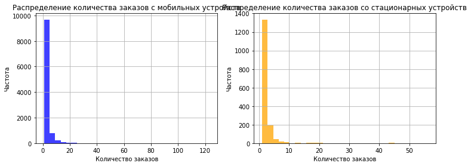

```
Выборочная дисперсия выборки с мобильными устройствами = 16.78, со стационарными устройствами = 9.35
```

```python
fig, (ax1, ax2) = plt.subplots(1, 2, figsize=(12, 4))

order_mobile['order_id'].plot(kind='hist', bins=30, alpha=0.75, color='blue', ax=ax1)
ax1.set_xlabel('Количество заказов')
ax1.set_ylabel('Частота')
ax1.set_title('Распределение количества заказов с мобильных устройств')
ax1.grid()

order_desktop['order_id'].plot(kind='hist', bins=30, alpha=0.75, color='orange', ax=ax2)
ax2.set_xlabel('Количество заказов')
ax2.set_ylabel('Частота')
ax2.set_title('Распределение количества заказов со стационарных устройств')
ax2.grid()

plt.show()

s_mobile = order_mobile['order_id'].var()
s_desktop = order_desktop['order_id'].var()
print(f'Выборочная дисперсия выборки с мобильными устройствами = {round(s_mobile, 2)}, со стационарными устройствами = {round(s_desktop, 2)}')
```

Распределения выборок не являются нормальными, но характер распределения одинаков. Размеры выборок большие (n₁ = 10939, n₂= 1618), значит работает центральная предельная теорема: выборочное распределение средних стремится к нормальному, даже если исходные данные не нормальны. Выборки независимы, дисперсии выборок не равны. Значит для проверки гипотезы можно применить тест Уэлча.

```python
results = ttest_ind(order_desktop['order_id'], order_mobile['order_id'], equal_var=False, alternative='less')
alpha = 0.05
p_value = results.pvalue
if p_value <= alpha:
    print(f"Полученное значение p_value={p_value} меньше критического уровня alpha={alpha}. Принимаем альтернативную гипотезу.")
    print("Среднее количество заказов на одного пользователя мобильного приложения выше по сравнению с пользователями стационарных устройств, и это различие статистически значимо")
else:
    print(f"Полученное значение p_value={p_value} больше критического уровня alpha={alpha}. Опровергнуть нулевую гипотезу нельзя.")
    print("Среднее количество заказов на одного пользователя мобильного приложения и стационарных устройств не различается.")
```

```
Полученное значение p_value=4.746050450629033e-25 меньше критического уровня alpha=0.05. Принимаем альтернативную гипотезу.
Среднее количество заказов на одного пользователя мобильного приложения выше по сравнению с пользователями стационарных устройств, и это различие статистически значимо
```

### 4.2. Гипотеза 2

Проверим гипотезу: среднее время между заказами пользователей мобильных приложений выше по сравнению с пользователями стационарных устройств.

- Нулевая гипотеза H₀: Среднее время между заказами пользователей мобильных приложений и стационарных устройств не различается.
- Альтернативная гипотеза H₁: Среднее время между заказами пользователей мобильных приложений выше по сравнению с пользователями стационарных устройств, и это различие статистически значимо.

```python
days_mobile = df_mobile[df_mobile['days_since_prev'] >= 0]['days_since_prev']
days_desktop = df_desktop[df_desktop['days_since_prev'] >= 0]['days_since_prev']
```

```python
count_mobile = days_mobile.shape[0]
count_desktop = days_desktop.shape[0]
print(f'Размер выборки с данными мобильных устройств = {count_mobile}, стационарных устройств = {count_desktop}')
```

```
Размер выборки с данными мобильных устройств = 24545, стационарных устройств = 2067
```

Размеры выборок существенно различаются (n₁ = 24545, n₂= 2067).

Проверим, одинаково ли распределены значения в выборках и равны ли дисперсии в этих выборках.

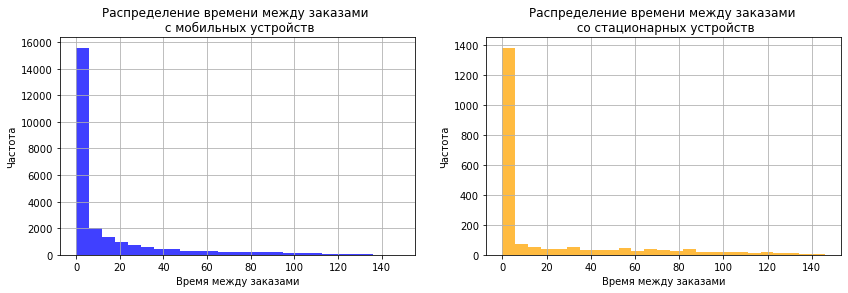

```
Выборочная дисперсия выборки с данными мобильных устройств = 661.11, со стационарных устройств = 1083.28
```

```python
fig, (ax1, ax2) = plt.subplots(1, 2, figsize=(14, 4))

days_mobile.plot(kind='hist', bins=25, alpha=0.75, color='blue', ax=ax1)
ax1.set_xlabel('Время между заказами')
ax1.set_ylabel('Частота')
ax1.set_title('Распределение времени между заказами \n с мобильных устройств')
ax1.grid()

days_desktop.plot(kind='hist', bins=25, alpha=0.75, color='orange', ax=ax2)
ax2.set_xlabel('Время между заказами')
ax2.set_ylabel('Частота')
ax2.set_title('Распределение времени между заказами \n со стационарных устройств')
ax2.grid()

plt.show()

s_mobile = days_mobile.var()
s_desktop = days_desktop.var()
print(f'Выборочная дисперсия выборки с данными мобильных устройств = {round(s_mobile, 2)}, со стационарных устройств = {round(s_desktop, 2)}')
```

Распределения выборок сильно правосторонне скошенные, дисперсии выборок не равны, выборки независимы. Значит для проверки гипотезы можно применить тест Манна-Уитни, так как он не чувствителен к выбросам.

```python
results = mannwhitneyu(days_mobile, days_desktop, alternative='greater')
alpha = 0.05
p_value = results.pvalue
if p_value <= alpha:
    print(f"Полученное значение p_value={p_value} меньше критического уровня alpha={alpha}. Принимаем альтернативную гипотезу.")
    print("Среднее время между заказами пользователей мобильных приложений выше по сравнению с пользователями стационарных устройств, и это различие статистически значимо.")
else:
    print(f"Полученное значение p_value={p_value} больше критического уровня alpha={alpha}. Опровергнуть нулевую гипотезу нельзя.")
    print("Среднее время между заказами пользователей мобильных приложений и стационарных устройств не различается.")
```

```
Полученное значение p_value=1.1044209586508845e-07 меньше критического уровня alpha=0.05. Принимаем альтернативную гипотезу.
Среднее время между заказами пользователей мобильных приложений выше по сравнению с пользователями стационарных устройств, и это различие статистически значимо.
```

#### Промежуточный вывод

- Для проверки гипотезы о том, что среднее время между заказами пользователей мобильных приложений выше по сравнению с пользователями стационарных устройств, был выбран двухвыборочный тест Манна-Уитни, так как распределения выборок сильно скошены вправо, а тест не чувствителен к выбросам.
- При оценке статистической значимости того, что среднее время между заказами пользователей мобильных приложений выше по сравнению с пользователями стационарных устройств, значение p-value 1.1×10⁻⁷ получилось ниже заданного уровня значимости 0.05, поэтому нет оснований принимать нулевую гипотезу о равенстве среднего времени между заказами. Это означает, что существует статистически значимое различие между временем заказов пользователей мобильного приложения и стационарного устройства.

## 5. Общий вывод и рекомендации

В ходе исследования были проанализированы данные о бронировании билетов на сервисе Яндекс Афиша за период с 1 июня по 31 октября 2024 года. Данные содержали информацию обо всех заказах билетов, совершённых с двух типов устройств — мобильных и стационарных, а также о событиях, включая город и регион события, о площадке проведения мероприятия. Данные были отфильтрованы по 99-му перцентилю показателей `revenue` и `tickets_count`. Были удалены 39 неявных дубликата по бронированию билета без учёта идентификаторов заказа. Всего в процессе предобработки данных было удалено 1.13% строк.

Рекомендации: